# PEMFC 캐소드 M² 모델 — τ=1.1, Lx=0.2mm 고η 탐색

노트북 셀별 해설: 물리 vs. 코드 · pemfc_lib.py 함수 전수 해설 · missing physics 탐구

PSE Lab

# Part 0. 좌표 잡기

## 0.1 이 노트북은 무엇을 묻는가

**파일명**: `PEMFC_Tau1_1_Lx0_2mm_HighEta_Exploration.ipynb`

Cell 0 원문(요약 번역):

> **논문과 독립적** — 순수한 호기심 탐색이다. τ=1.1, Lx=0.2mm 설정은 이미 η=0.62까지 fold 없이 매끄럽게 도달하는 것이 확인되어 있다. 이 설정이 η=0.62~1.5 사이에서 뭔가 흥미로운 구조(fold, 느려짐, 질적 변화)를 만나는지를 본다.

> 이 프로젝트에서 써온 것과 같은 적응 스텝 continuation(진짜 restore-on-failure + step halving, 실시간 로깅, Drive 백업 + 이미 계산된 것 건너뛰기)을 쓴다. η=1.5까지 깨끗이 도달하면 그 자체로 의미 있다(이 설정에는 물리적으로 타당한 범위 안에 fold가 아예 없을 수 있다는 뜻). 만약 멈추면(`ds`가 `ds_min` 아래로 줄어들면) 그 지점은 후속 조사(arclength continuation, SVD 진단 등)의 진짜 후보다 — **이 노트북에서는 하지 않는다**. 이 노트북은 그저 평범한 적응 스테퍼를 갈 수 있는 데까지 밀어붙이고 무슨 일이 일어나는지 보고할 뿐이다.

**핵심**: 이건 검증 노트북이 아니라 **정찰 노트북**이다. 목적은 “이 파라미터 조합에 장애물이 있는가, 있다면 어디인가”를 값싸게 알아내는 것.

## 0.2 왜 τ=1.1, Lx=0.2mm인가 — 논문과의 관계

- `tau_brug`(Bruggeman 굴곡도 지수): 논문에 **숫자가 없다**. 코드 기본값 1.5는 문헌 통상값. 이번 실행은 이를 **1.1로 낮춘 것** — 다공체가 덜 구불구불하다고 가정한 것과 같다.
- `Lx`(GDL 두께): 논문 기본값(Table 2와 코드 `DEFAULT_PARAMS` 모두) **0.30 mm**. 이번 실행은 **0.20 mm**로 낮췄다.
- 두 변경 모두 “물질전달 저항을 줄이는” 방향 — GDL을 얇게, 굴곡도를 낮게. 고전류·고η 영역에서 무슨 일이 일어나는지 보려는 의도와 일치한다.
- 참고로 논문 Fig. 21/22 자체가 GDL 두께를 0.00015~0.001 m 사이에서 스윕하며, **0.0002 m(=0.2mm)이 그 스윕값 중 하나다**. 이번 실행의 Lx는 논문이 이미 실험한 값과 정확히 겹친다 — 임의의 선택이 아니다.

## 0.3 노트북 15셀 → 4블록 구조

```
Cell 0-1   [markdown]  제목 / 섹션 표시
Cell 2     [code]      Colab에 FEniCSx 0.11 설치
Cell 3-4   [md+code]   JIT 캐시 방어적 삭제
Cell 5     [markdown]  물리 모듈 섹션 표시
Cell 6     [code]      pemfc_lib.py 전체 작성 (3636줄, 23개 함수)
Cell 7-8   [md+code]   Google Drive 마운트
Cell 9-10  [md+code]   본 실행: 적응 continuation, η→1.5
Cell 11-12 [md+code]   결과 플롯
Cell 13-14 [md+code]   결과 zip 다운로드
```

이 중 실제로 **물리 계산**을 담당하는 것은 Cell 6(라이브러리 정의)과 Cell 10(실행)뿐이다. 나머지는 환경설정·입출력이다. 이 슬라이드는 Cell 6과 Cell 10에 가장 많은 분량을 쓴다.

## 0.4 미리 보기 — base case와의 대조

같은 물리 모델을 **τ=1.5, Lx=0.3mm**(base case, 별도 노트북)로 돌린 결과가 있다. 이번 실행과 겹치는 η 구간을 대조하면:

| η | base I (A/cm²) | 이번 실행 I | base s_max | 이번 실행 s_max |
| --- | --- | --- | --- | --- |
| 0.30 | 0.2938 | 0.2979 | 0.01005 | 0.0103 |
| 0.32 | 0.3833 | 0.3909 | 0.01114 | 0.0106 |
| 0.34 | 0.4875 | 0.5014 | 0.01572 | 0.0113 |
| 0.35 | 0.5406 | (~0.564) | **0.09089** | ~0.012 |

전류는 두 설정에서 거의 같다(차이 1~4%). 갈라지는 것은 오직 **flooding 개시 시점**: base는 η=0.35에서 이미 s_max가 튀어 오르지만, 이번 설정은 η=0.39에야 튄다. τ↓·Lx↓가 전류-전압 관계 자체를 바꾸는 게 아니라 **물이 언제 차오르기 시작하는지를 늦춘다** — 이 관찰이 Part 4의 결과 해석 전체를 지배한다.

# Part 1. 실행 환경 (Cell 2, 3-4, 7-8)

## 1.1 Colab에 FEniCSx 0.11 설치 (Cell 2) — ⚙️ 코드

```python
REPO_URL = 'https://github.com/seoultechpse/fenicsx-colab.git'
...
N_PROC = 4
with open('/root/hostfile', 'w') as f:
    f.write(f'localhost slots={N_PROC}\n')
os.environ['OMPI_MCA_rmaps_default_mapping_policy'] = 'slot:OVERSUBSCRIBE'
os.environ['PRTE_MCA_rmaps_default_mapping_policy'] = 'slot:OVERSUBSCRIBE'
...
get_ipython().run_line_magic('run', f"{REPO_DIR / 'setup_fenicsx.py'} {' '.join(opts)}")
```

**문제**: Colab의 컨테이너는 물리 코어 수가 적을 때가 많고, OpenMPI 5.x의 새 런타임(PRRTE)은 기본적으로 “요청한 슬롯 수만큼 실제 코어가 없으면 거부”한다.

**대책**: `hostfile`에 슬롯 수를 명시하고, `OVERSUBSCRIBE` 정책으로 강제 허용. 이 노트북 자체는 `%%fenicsx -np 1`(1 프로세스)만 쓰므로 이 패치가 결과에 영향을 주지는 않지만, 없으면 MPI 초기화 자체가 실패한다.

DOLFINX_VERSION을 `'0.11'`로 고정 — 프로젝트 전체가 이 버전에 맞춰 검증되었기 때문에, Colab 런타임이 갱신되어도 재현성이 깨지지 않도록 버전을 못박은 것.

## 1.2 FFCx JIT 캐시 방어적 삭제 (Cell 3-4) — ⚙️ 코드

```python
cache_dir = "/root/.cache/fenics"
if os.path.exists(cache_dir):
    shutil.rmtree(cache_dir)
```

**문제**: FFCx(FEniCSx의 폼 컴파일러)는 UFL 폼을 C 코드로 컴파일한 뒤 캐시한다. `%%fenicsx` 셀이 컴파일 도중 중단되면(수동 정지, 런타임 연결 끊김) 캐시 디렉터리에 **반쯤 쓰인 파일**이 남는다.

**증상**: 다음 실행에서 같은 폼을 다시 컴파일하려 하면 `FileExistsError` → `TimeoutError: JIT compilation timed out, probably due to a failed previous compile`. 원래 중단을 일으킨 코드 문제를 고쳐도 이 에러는 계속 남는다.

**대책**: 런타임을 통째로 재시작하면 해결되지만 느리다. 이 셀을 다시 실행하는 게 더 빠르고 다른 세션 상태를 잃지 않는다.

## 1.3 Google Drive 마운트의 위치 (Cell 7-8) — ⚙️ 코드

```python
import os
from google.colab import drive
if not os.path.ismount('/content/drive'):
    drive.mount('/content/drive')
```

이 코드는 **일부러 평범한 코드 셀**에 있다(`%%fenicsx` 매직 안이 아님).

**이유**: `%%fenicsx` 셀은 별도의 subprocess에서 실행되며, 그 프로세스에는 `google.colab` 패키지가 없다. Drive를 마운트하려면 `%%fenicsx` 밖에서, Colab의 메인 커널 프로세스에서 먼저 해야 한다. Cell 10(본 실행)의 첫머리에는 이 마운트가 이미 되어 있다는 것을 `assert`로 확인만 한다:

```python
assert os.path.ismount('/content/drive'), (
    "Drive not mounted -- run the 'Mount Google Drive' cell above first ...")
```

## 1.4 캐싱 전략: skip-if-complete

```python
DRIVE_BACKUP = "/content/drive/MyDrive/pemfc_tau1.1_Lx0.2mm_higheta_backup"
...
for fname in os.listdir(DRIVE_BACKUP):
    local_fp = os.path.join(OUT, fname)
    if not os.path.exists(local_fp):
        shutil.copy2(os.path.join(DRIVE_BACKUP, fname), local_fp)
```

이번 실행 전용 백업 폴더가 base case 노트북의 백업 폴더와 **완전히 분리**되어 있어, 두 노트북을 다른 Colab 세션에서 동시에 돌려도 서로 덮어쓰지 않는다. 결과 파일이 이미 있고 `complete=True`면 계산을 건너뛴다 — 48분짜리 실행을 실수로 두 번 돌리지 않기 위한 장치.

# Part 2. 물리 모델과 라이브러리 (Cell 6, `pemfc_lib.py`)

## 2.0 Cell 6이 하는 일

```python
%%writefile /content/pemfc_lib.py
```

이 한 줄짜리 매직이 이하 3636줄 전체를 `/content/pemfc_lib.py` 파일로 디스크에 쓴다. 즉 Cell 6은 계산을 하지 않고, **다른 셀들이 import할 모듈을 생성**할 뿐이다. 물리·수치 로직은 전부 이 안에 있다.

모듈 헤더 주석이 이 파일 하나를 이렇게 요약한다:

> FEML / PSE Lab — PEM Fuel Cell Cathode, M² Two-Phase Mixture Model. Abdollahzadeh et al., Energy 68 (2014) 478–494, Table 1을 재현하되, Chang, Chen & Teng, J. Power Sources 160 (2006) 268–276(같은 M² 계열, γ·jl·Leverett J(s)·Bruggeman D_eff에 대한 완전히 닫힌 형태를 제공)로 교차검증·수정함.

## 2.1 도메인과 경계조건 — 🧪 물리

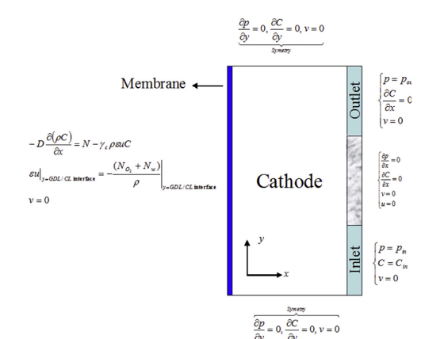

Fig. 3 — 논문의 2D 계산 도메인과 경계조건

- **membrane** (x=0): 왼쪽 경계. 여기서 산소가 소비되고 물이 생성된다 (Tafel 반응이 여기 걸린다).
- **channel 쪽** (x=Lx): 세 구간으로 나뉜다 — **inlet**(가스 유입, Dirichlet), **rib**(고체 접촉면, 자연 무플럭스), **outlet**(가스 배출, Neumann형 유출).
- **상·하 경계**: 대칭 조건 (`∂p/∂y=0` 등).

코드의 facet tag 4종이 정확히 이 네 구간에 대응한다:

```python
TAG_MEMBRANE, TAG_INLET, TAG_RIB, TAG_OUTLET = 1, 2, 3, 4
def on_membrane(x): return np.isclose(x[0], 0.0)
def on_inlet(x):    return np.isclose(x[0], Lx) & (x[1] <= y_inlet_end + 1e-12)
def on_rib(x):      return np.isclose(x[0], Lx) & (x[1] > y_inlet_end + 1e-12) & (x[1] <= y_rib_end + 1e-12)
def on_outlet(x):   return np.isclose(x[0], Lx) & (x[1] > y_rib_end + 1e-12)
```

`rib`에 대해서는 BC를 **아무것도 걸지 않는다** — 약형식에 경계적분 항을 추가하지 않으면 자연스럽게 무플럭스(고체 벽) 조건이 된다.

## 2.2 M² 모델이란 무엇인가 — 🧪 물리

두 상(기체·액체)을 각각의 방정식으로 풀지 않고, **혼합체(mixture) 하나**로 뭉쳐서 푸는 방법.

- 혼합 밀도 $\rho = \rho_g(1-s) + \rho_l s$ (Eq. 4)
- 혼합 속도 $\rho \mathbf u = \rho_g \mathbf u_g + \rho_l \mathbf u_l$ (Eq. 13)
- 혼합 농도 $\rho C^\alpha = \rho_l s C_l^\alpha + \rho_g(1-s)C_g^\alpha$ (Eq. 11)

이렇게 하면 상마다 별도 운동량 방정식을 풀 필요가 없어지고, **압력 1개 + 종 농도 2개**(물, 산소)만 풀면 된다 — 코드의 미지수가 정확히 이 3개(`p, C_w, Cg_O2`)인 이유. 두 상 사이의 차이는 `s`(포화도)를 통해 물성치(밀도·점도·이동도)에 스며든다.

## 2.3 지배방정식 강형식 — 🧪 물리

Chang Eq. 1–3 / Abdollahzadeh Eq. 1–3 (연속식·운동량·종보존):

$$\nabla\cdot(\rho\mathbf u) = 0$$
$$\varepsilon\frac{\partial}{\partial t}(\rho C^\alpha) + \nabla\cdot(\gamma_\alpha \rho\mathbf u C^\alpha)
= \nabla\cdot(\varepsilon\rho D^\alpha\nabla C^\alpha) - \nabla\cdot\left[(C_l^\alpha-C_g^\alpha)\mathbf j_l\right]$$

이 노트북은 **정상상태**(시간항 없음)이고, 운동량은 관성·점성항을 버린 순수 Darcy 극한으로 축소한다 (§2.4에서 다룸). 따라서 실제로 푸는 3개 잔차는:

1. 압력: $\nabla\cdot(\kappa\nabla p)=0$ (경계에서만 소스)
2. 물 질량분율 $C_w$의 이송-확산-모세관 방정식
3. 산소 질량분율 $Cg_{O2}$의 이송-확산-모세관 방정식

그리고 포화도 $s$는 **별도의 방정식이 아니라** $C_w$의 대수적 함수(Eq. 16)로 닫힌다 — 이것이 이 코드의 가장 중요한 설계 결정이며 §2.9에서 자세히 다룬다.

## 2.4 운동량: 논문의 Brinkman vs 코드의 순수 Darcy — 🧪 물리

Abdollahzadeh Eq. 2 (완전한 형태):

$$\nabla\cdot(\varepsilon\rho\mathbf u\mathbf u) = \nabla\cdot(\varepsilon\mu\nabla\mathbf u) - \varepsilon\nabla p + \varepsilon(\rho_l\lambda_l+\rho_g\lambda_g)g - \varepsilon^2\frac{\mu}{K}\mathbf u$$

관성항(좌변)·점성항(우변 1항)·중력항까지 포함한 Brinkman-확장 다공체 운동량식이다.

코드가 실제로 쓰는 형태 (Cell 10):

```python
u_darcy = -(kappa / rho_mix) * ufl.grad(p_sol)
```

**순수 Darcy 법칙**만 남긴 것 — 관성·점성·중력을 모두 버렸다. 다공체 내부 유동은 Reynolds 수가 극히 작아(공극 스케일 μm, 속도 mm/s 미만) 관성항이 점성 저항항보다 몇 자리 작다는 표준적인 다공체 유동 근사다. 논문도 사실상 이 극한에서 계산했을 가능성이 높다 (SIMPLE 알고리즘에 저Re 다공체 저항이 압도적이면 결과는 거의 동일).

## 2.5 s(C_w): 평형 관계 — 🧪 물리

Abdollahzadeh Eq. 16:

$$s = \frac{\rho_g(C-C_g^{sat})}{\rho_l(C_l^{sat}-C) + \rho_g(C-C_g^{sat})}$$

이 식의 의미: 물의 질량분율 $C$가 기체상의 포화 농도 $C_g^{sat}$를 넘어서면, 그 초과분이 **순간적으로** 액체로 응축된다고 가정한다 — **열역학적 평형**. 응축·증발의 속도론(kinetics)은 없다. $C \le C_g^{sat}$이면 $s=0$(단상, 수증기만), $C$가 커질수록 $s\to 1$(거의 순수 액체)에 접근한다.

코드의 대응 (스무딩 포함, §2.9에서 자세히):

```python
def s_expr(Cw):
    raw = rho_g_const * (Cw - Cg_sat) / (
          rho_l * (Cl_sat - Cw) + rho_g_const * (Cw - Cg_sat) + 1e-12)
    s_smooth = 0.5 * (raw + ufl.sqrt(raw**2 + s_smooth_eps**2))
    ...
    return ufl.min_value(s_smooth, s_max_cap)
```

## 2.6 Leverett 함수와 소수성/친수성 — 🧪 물리

모세관압 $p_c = \sigma\cos\theta_c(\varepsilon/K)^{1/2}J(s)$ (Chang Eq. 17). $J(s)$는 다공체 내 모세관압을 포화도의 함수로 준경험적으로 맞춘 3차 다항식(Leverett, 1941 원형):

- 친수성(θ_c<90°): $J(s)=1.417(1-s)-2.120(1-s)^2+1.263(1-s)^3$ (Chang Eq. 18)
- 소수성(θ_c>90°): $J(s)=1.417s-2.120s^2+1.263s^3$ (Chang Eq. 19)

코드:

```python
def J_leverett(s, hydrophobic=True):
    if hydrophobic:
        return 1.417*s - 2.120*s**2 + 1.263*s**3
    u = 1.0 - s
    return 1.417*u - 2.120*u**2 + 1.263*u**3
```

이번 실행의 GDL은 `theta_c_deg=91`(기본값, 미변경) — 소수성 쪽. 소수성 GDL은 물을 밀어내는 방향으로 모세관력이 작동해 배출을 돕는다(논문 §4.9의 결론과 일치).

## 2.7 상대투과도와 혼합 이동도 — 🧪 물리

Corey 상대투과도 (Chang Eq. 12–13, `n=3`으로 두 논문 모두 확정):

$$k_{rl}=s^n,\qquad k_{rg}=(1-s)^n$$

이동도 $\lambda_l, \lambda_g$ (Chang Eq. 10–11):

$$\lambda_l = \frac{k_{rl}/\nu_l}{k_{rl}/\nu_l+k_{rg}/\nu_g},\qquad \lambda_g=1-\lambda_l$$

코드:

```python
krl = s ** n_corey
krg = (1.0 - s) ** n_corey
lam_l = (krl / mu_l) / (krl / mu_l + krg / mu_g + 1e-30)
lam_g = 1.0 - lam_l
```

물리적 의미: $\lambda_l$은 “전체 흐름 중 액상이 담당하는 몫”. $s=0$이면 $\lambda_l=0$(액상 흐름 없음), $s\to1$이면 $\lambda_l\to1$.

## 2.8 모세관 확산계수 Dc, Γ — 🧪 물리 (핵심 수정 지점)

Chang Eq. 20 (jl을 s의 확산 형태로 재정리):

$$\mathbf j_l = \frac{K\lambda_l\lambda_g}{\nu}\,\sigma\cos\theta_c\left(\frac{\varepsilon}{K}\right)^{1/2}\frac{dJ}{ds}\nabla s$$

코드:

```python
Dc = ((lam_l * lam_g * K_perm / (nu_mix + 1e-30))
      * sigma_st * np.cos(theta_c) * (eps_p / K_perm) ** 0.5 * dJds)
Gamma = Dc * (1.0 - Cg_sat) / (rho_l - rho_g_const * Cg_sat)
```

$D_c$는 Chang Eq. 20의 계수 부분 그대로, $\Gamma$는 이 계수를 물 질량분율 $C_w$ 확산항 형태로 다시 환산한 것(Abdollahzadeh Eq. 25의 역할). `Gamma * rho_mix` 항이 `Diff_w`에 더해져 **물의 총 확산계수**(기체상 확산 + 모세관 확산)를 이룬다.

## 2.9 `(ε/K)^½` vs `(Kε)^½` — 논문 내부 모순과 코드의 판단 ⚠️ — 🧪 물리

같은 Abdollahzadeh 논문 안에서:

- **Eq. 10**: $p_c = \sigma\cos\theta_c\left(\dfrac{\varepsilon}{K}\right)^{1/2}J(s)$
- **Eq. 22, 25**: $\left(K\varepsilon\right)^{1/2}$

두 스케일링은 차원은 같지만 **값이 다르다** ($K\sim10^{-12}$이므로 $\varepsilon/K$와 $K\varepsilon$은 24자리 차이). Chang 논문은 Eq. 17과 Eq. 20 모두에서 일관되게 $(\varepsilon/K)^{1/2}$를 쓴다.

코드:

```python
Dc = (... * (eps_p / K_perm) ** 0.5 * dJds)
```

**`(ε/K)^½`를 채택** — Chang의 일관된 표기, 그리고 Abdollahzadeh 자신의 Eq. 10과 일치. Eq. 25 쪽이 저자 측 오타로 판단된다. 이런 종류의 불일치는 논문 재현 작업에서 흔하며, **다른 소스(Chang)로 교차검증**하지 않았다면 발견하기 어려웠을 것이다.

## 2.10 γ^α: advection correction factor — 🧪 물리

Chang Eq. 9:

$$\gamma_\alpha = \frac{\rho(\lambda_l C_l^\alpha+\lambda_g C_g^\alpha)}{\rho_l s C_l^\alpha + \rho_g(1-s)C_g^\alpha}$$

이건 “유도된 결과”가 아니라 **정의**다 — $\gamma_\alpha \cdot \rho C^\alpha \equiv \rho(\lambda_l C_l^\alpha + \lambda_g C_g^\alpha)$가 항등식이 되도록 $\gamma_\alpha$를 그렇게 정의한 것. 혼합체 이송 방정식의 대류항을 상별 이송의 합으로 정확히 되돌리기 위한 장치.

코드는 이 인자를 명시적으로 계산하지 않고, 물에 대해서는 `Weff_w`(§3.3), 산소에 대해서는 `lam_g`(§3.5) 형태로 **이미 대입이 끝난 형태**로 약형식에 등장한다 — γ^α를 세우고 다시 곱하는 대신, Chang Eq. 24/29가 유도해 준 닫힌 형태를 바로 쓴다.

## 2.11 Tafel 반응과 막 플럭스 — 🧪 물리

Tafel 식 (Abdollahzadeh Eq. 32):

$$I=(1-s)I_{ref}\frac{C_g^{O2}|_{catalyst}}{C_{g,ref}^{O2}}\exp\left(\frac{\alpha_c F}{RT}\eta\right)$$

$(1-s)$ 인자: 촉매 표면이 물로 덮이면 반응 활성면적이 줄어든다는 것을 나타내는 차단 인자.

막 플럭스 (Eq. 27–28):

$$N_{O2}=\frac{M_{O2}}{4F}I,\qquad N_w=\frac{M_w(1+2\alpha_w)}{2F}I$$

코드:

```python
C_O2_molar = rho_g_const * CgO2_sol / M_O2
I_local = (1.0 - s) * I0 * (C_O2_molar / C_O2_ref) * ufl.exp(alpha_c * F * eta_const / (R * T_cell))
N_O2_expr = (M_O2 / (4.0 * F)) * I_local
N_w_expr = (M_H2O * (1.0 + 2.0 * alpha_w) / (2.0 * F)) * I_local
```

## 2.12 Tafel 기준 농도의 단위 불일치 — 🧪 물리

Abdollahzadeh Eq. 32의 $C_g^{O2}/C_{g,ref}^{O2}$는 **질량분율의 비**(무차원)로 읽히지만, Table 2는 $C_{ref}^{O2}=40$ **mol/m³**로 준다 — 단위가 다르다.

코드는 몰농도로 변환해서 나눈다:

```python
C_O2_molar = rho_g_const * CgO2_sol / M_O2   # 질량분율 -> mol/m^3
I_local = (1.0 - s) * I0 * (C_O2_molar / C_O2_ref) * ...
```

`C_O2_ref=40`(Table 2 그대로, mol/m³)과 단위를 맞춘 것 — 논문 본문 식보다 Table 2의 숫자를 신뢰한 판단.

## 2.13 막 압력 Neumann BC의 부호 — 🧪 물리

논문 Eq. 29: $\varepsilon u|_{interface} = -\dfrac{N_{O2}+N_w}{\rho}$ (합, 음수).

코드 주석: `kappa*dp/dn = N_w - N_O2` (차이).

겉보기엔 다르지만, Eq. 28에서 $N_w$ 자체가 이미 음의 부호 관례로 정의돼 있어 규약을 풀어내면 **같은 물리량**이 된다 (양쪽 다 $\alpha_w=0.5$에서 $+0.010\,I/F$ 수준). 코드 주석이 “O2와 H2O 두 가지 독립적인 방법으로 교차검증했다”고 적어둔 부분이 실제로 맞다.

## 2.14 `DEFAULT_PARAMS` ↔︎ 논문 Table 2/3 대조표 — ⚙️ 코드

| 코드 키 | 값 | 논문 출처 |
| --- | --- | --- |
| `K_perm` | 1.2e-12 m² | Table 2 |
| `eps_p` | 0.30 | Table 2 |
| `p_in`, `p_out` | 1.007e5, 1.0e5 Pa | Table 2 |
| `mu_g` | 2.03e-5 kg/m·s | Table 2 (333K) |
| `D_O2_g`, `D_H2O_g` | 1.775e-5, 2.56e-5 m²/s | Table 2 |
| `I0` | 100 A/m² | Table 2 |
| `alpha_c`, `alpha_w` | 0.5, 0.5 | Table 2 |
| `T_cell` | 330 K | Table 2 |
| `C_O2_ref` | 40 mol/m³ | Table 2 |
| `theta_c_deg` | 91° | Table 2 |
| `sigma_st` | 0.0625 N/m | Table 2 |
| `w_ch`, `w_rb` | 0.8, 1.2 mm | Table 3 |
| `Lx` (GDL 두께) | **0.30 mm (기본)** | Table 2 base case |

## 2.15 논문에 없는 파라미터 — 성격 명시 — ⚙️ 코드

말씀하신 대로, 아래는 전부 “**논문에 없어서 통상값이나 추정값을 쓴 것**”으로 분류된다 — 오류가 아니라 명시적 가정.

[output not shown]

`Lx=0.20mm`는 이 표에 들어가지 않는다 — §0.2에서 확인했듯 논문 자체의 스윕값(Fig. 21/22) 중 하나이기 때문이다.

## 2.16 개발사 ① — Picard 6가지 대책의 전패 — ⚙️ 코드

모듈 헤더 주석이 기록한 이력(요약):

> 이전 버전은 분리(segregated) Picard 반복을 썼다: 압력 → 물 → 산소를 순서대로, 앞 반복의 값으로 계수를 고정해서 각각 풀고, 포화도 s는 별도 필드로 추적해 C_w로부터 갱신한 뒤(지연된 채로) 나머지 세 방정식의 계수에 되먹였다. 여섯 가지 서로 다른 대책 — 고정 완화, s에만 적용한 적응(bold-driver) 완화, 세 필드 모두로 확장하고 제대로 된 atol+rtol 수렴판정 적용, s(C_w)의 꺾임 스무딩, 적응 η 스텝 절반화 continuation, 마지막으로 ~1% 완화된 수렴 허용오차 — 을 순서대로 시도했지만 **포화도가 유의미해지자마자(대략 η≳0.33–0.35V) 전부 실패**했다: Picard는 그 구간의 모든 η 스텝에서 반복 상한까지 수렴하지 못했고, 스텝 크기와 무관했다(η 증분을 원래 크기의 1/32까지 이분해도 도움이 안 돼 “스텝이 너무 크다”는 가설은 배제됨).

## 2.17 개발사 ② — 진단: 문제는 s와 C_w 사이의 lag — ⚙️ 코드

> “s가 유의미해지는 지점에서 정확히, damping·매끄러움·스텝 크기·허용오차와 무관하게 일관되게 실패한다”는 패턴은 **분리된(segregated) s와 C_w 사이의 lag 자체**가 구조적 문제임을 가리켰다 — 어떤 특정 수치적 대책의 튜닝 문제가 아니라.

**해법**: 그 lag를 아예 없앤다. $s$는 이미 $C_w$에 대해 매끄러우므로(`s_smooth_eps` 덕분), 별도로 추적되는 지연된 필드가 아니라 $C_w$의 **미분 가능한 UFL 표현식**으로 곳곳에 직접 대입한다(혼합 밀도·점도·Darcy 계수·모세관 확산·Bruggeman 확산계수·Tafel BC의 (1-s) 인자 전부). $\nabla s$도 UFL의 연쇄법칙을 통해 공짜로 따라온다 — 별도의 L2 투영 단계가 필요 없다. 압력·물·산소를 **하나의 mixed 함수공간**에 합쳐 dolfinx의 Newton 솔버(PETSc SNES)로 **한 번에** 풀며, 이는 UFL 자동미분을 통한 완전한 해석적 Jacobian과 해 근처에서의 진짜 2차 수렴을 준다 — 손으로 댐핑을 튜닝하는 고정점 반복이 아니라.

## 2.18 개발사 ③ — 논문 Eq. 31 vs 이 코드의 Newton — 🧪+⚙️

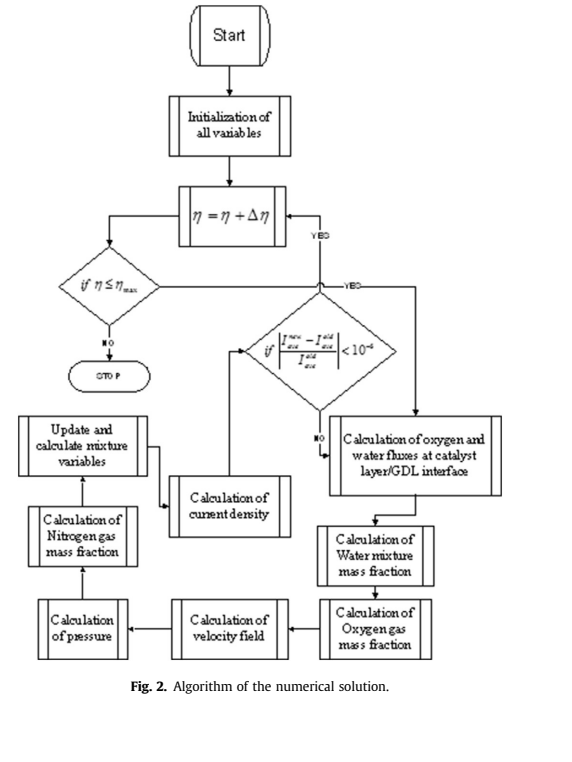

Fig. 2 — 논문의 SIMPLE 반복 알고리즘

논문(§3.1)은 촉매층 경계조건(Eq. 30)이 “고도로 비선형”임을 인지하고, 이산화된 계수가 급변해 반복이 진동하거나 발산할 수 있다고 서술한다. 대책으로 **under-relaxation**을 제안한다 (Eq. 31):

$$C_{i-1} = (1-\beta)C_{i-1} + \beta\left(\frac{\Gamma_i}{\Gamma_{i-1}}C_i + \frac{(-N+\gamma_\alpha\rho\varepsilon vC_{i-1})\Delta x}{\Gamma_{i-1}}\right),\quad 0<\beta\le1$$

**이 코드에서는 이 대책 자체가 필요 없어진다.** Newton이 잔차 전체(경계항 포함)의 해석적 Jacobian을 갖고 있으므로, 비선형 경계조건의 “급변하는 계수”도 Jacobian의 일부로 정확히 반영된다. 손으로 β를 튜닝하는 대신 SNES의 line search(`newtonls`)가 스텝 크기를 자동 조절한다. 같은 병(비선형 경계조건의 발산 위험)에 대해 논문은 완화로, 이 코드는 완전한 선형화로 대응한 것.

## 2.19 SUPG 안정화 — 현재 이 (Newton) 모듈에서는 비활성 — ⚙️ 코드

모듈 헤더 주석:

> Fig. 8의 단상 vs 이상 국소전류밀도 프로파일을 비교하면서 추가되었다: 이상 곡선이 단상에서는 없던 심한 node-to-node 진동을 채널 방향으로 보였다. 원인 진단: 고 s에서(예: s=0.9일 때 원래 값의 ~1%) Bruggeman으로 줄어든 $D_{eff}=[\varepsilon(1-s)]^\tau D$가 막의 대류 플럭스와 결합해 국소 Péclet 수를 안정화되지 않은 P1 갤러킨이 진동하는 영역까지 밀어올린다. 표준 SUPG를 물·산소 방정식 모두에 추가했고($\tau=1/\sqrt{(2|a|/h)^2+(4D/h^2)^2}$, $h$=셀 지름), 처음엔 3-필드 결합 Newton 시스템 전체의 FFCx JIT 컴파일이 멈추는 것처럼 보였다 — 하지만 SUPG 없는 기준선과 비교해 격리된 적이 없어서, SUPG가 실제 원인인지 아니면 기저 결합 자체가 원래 컴파일이 비싼 것인지 확인되지 않았다. 작동하는 기준선을 얻기 위해 여기서는 제거했다.

**함의**: 이번 실행처럼 τ가 낮아 D_eff 감쇠가 상대적으로 덜한 설정에서는 SUPG 없이도 버틸 여지가 있지만, 원칙적으로 이 코드는 고 Péclet 영역에서 진동 위험을 안고 있다. Part 5의 탐구 주제로 이어진다.

## 2.20 온도 의존 교환전류밀도 I0(T) — 🧪 물리

> Table 2가 명시적으로 $I_0=100\text{ A/m}^2$ “(at 333.0 K)”라고 라벨을 달았고, §4.3은 “운전온도 증가는 반응속도론 향상을 통해 산소환원반응 속도를 높여 연료전지 성능을 높인다(기준전류밀도의 증가)”고 명시한다 — 즉 $I_0$ 자체가 T와 함께 올라가야 한다는 뜻이다. 이전 버전은 전체 T 스윕에서 $I_0$를 상수로 고정해, 고정 η에서 T가 올라갈수록 I가 **감소**하는(논문과 반대) 결과를 냈다. Table 2는 자체 Ea 수치를 주지 않으므로(GDL 두께나 Bruggeman τ처럼 이 논문의 또 다른 미명시 항목), $Ea=72.4$ kJ/mol을 사용한다 — Pt ORR 활성화에너지로 널리 인용되는 표준 문헌값.

코드:

```python
I0 = I0_ref * np.exp(-(Ea_orr / R) * (1.0 / T_cell - 1.0 / T_ref_I0))
```

`T_ref_I0=330K`(Table 2의 “333.0K” 라벨이 아니라 실제 base case 운전온도)에 고정한 이유: 이렇게 해야 base case(T=330K)에서 $I_0$가 정확히 100으로 남아 이미 검증된 Fig. 4 재현이 흔들리지 않는다.

## 2.21 이 노트북이 실제로 쓰는 4개 함수 — ⚙️ 코드

Cell 6의 3636줄 중, Cell 10이 실제로 import하는 것은:

```python
from pemfc_lib import DEFAULT_PARAMS, Psat_atm, _smooth_outflow, _project_scalar_standalone
```

**단 4개.** `run_case`, `run_case_arclength`, `diagnose_fold_point`, `fold_svd_sweep` 등 나머지 19개 함수는 이 실행에서 **호출되지 않는다**. Cell 10은 오히려 `build_problem()`이라는 자체 함수를 다시 작성해 물리 설정을 처음부터 재현한다(§3에서 다룸). 이는 §2.D에서 볼 수 있듯, 이 라이브러리가 **이 노트북 하나만을 위한 것이 아니라 프로젝트 전체의 도구 상자**이기 때문이다 — fold 진단, arclength continuation, 체크포인트 롤백 등은 다른 노트북(base case, arclength 세션)에서 쓰인다.

## 2.D `pemfc_lib.py` 함수 전수 해설 (23개)

각 함수마다: **무슨 문제가 있어서 / 무엇을 검증하려고** 이 코드를 썼는지를 중심으로 정리한다. 이번 노트북이 실제로 쓰는 것은 4개뿐이지만(§2.21), 나머지도 프로젝트 전체의 맥락에서는 필수적이다.

## 함수 1/23 — `_progress_log(line)`

```python
def _progress_log(line):
    with open(PROGRESS_LOG, "a") as f:
        f.write(f"[{time.strftime('%H:%M:%S')}] {line}\n")
        f.flush()
        os.fsync(f.fileno())
```

**문제**: `%%fenicsx` 매직은 셀의 stdout을 **셀 전체가 끝나거나 에러가 날 때까지 버퍼링**하는 것으로 보인다. `print(..., flush=True)`는 파이썬 자체의 버퍼는 비우지만, 매직이 그 위에서 하는 무언가는 비우지 못한다.

**해결**: 파일에 직접 쓰고 `f.flush()` + `os.fsync()`로 OS 버퍼까지 강제로 디스크에 반영한다. 이렇게 하면 **다른 셀**(진행 상황을 보려고 로그 파일을 폴링하는)이 아직 실행 중인 긴 계산의 실시간 진행을 볼 수 있다. 48분짜리 실행을 무작정 기다리지 않게 해주는 유일한 방법.

## 함수 2/23 — `_classify_branch_state(eta_val, s_max_val, deta_sign)`

```python
if s_max_val < 0.05: phase = "near-single-phase"
elif s_max_val < 0.3: phase = "light flooding"
elif s_max_val < 0.6: phase = "moderate flooding"
elif s_max_val < 0.9: phase = "severe flooding"
else: phase = "near-saturated (s~cap)"
```

**문제**: 체크포인트나 스냅샷이 저장될 때마다 (η, s_max, 방향)만 봐서는 “이게 어느 국면인지” 한눈에 알기 어렵다.

**해결**: 엄밀한 분기 식별이 아니라(docstring이 스스로 “NOT a rigorous branch identifier”라고 명시), s_max 구간별로 사람이 읽을 수 있는 라벨을 붙이는 휴리스틱. 재개한 실행이 예상한 지점에서 이어졌는지, 저장된 스냅샷들을 훑어보다 흥미로운 것을 고를 때 매번 수동으로 η/s_max/방향을 대조하지 않아도 되게 해준다.

## 함수 3/23 — `_jacobian_singular_values(problem, n_smallest=6, n_largest=3)`

**문제**: fold(전환점)의 수학적 정의는 “그 지점에서 Jacobian이 특이(singular)해진다”는 것이다. 이를 직접 확인하려면 특이값 스펙트럼이 필요하다.

**왜 raw 스펙트럼은 못 쓰는가**: 이 monolithic (p, C_w, Cg_O2) 시스템은 압력(~1e5 Pa)과 질량분율(<sub>0.01</sub>1)이 자연 스케일에서 5~7자리 차이가 나고, Dirichlet BC 행은 정확히 단위행렬로 설정된다 — 둘 다 fold 근접성과 무관한, 크지만 거의 **일정한**(η에 안 변하는) 조건수 바탕값을 만들어 진짜 fold 신호를 압도한다.

**해결**: Jacobi(대각) 등화 — 각 행/열을 `1/sqrt(|대각원소|)`로 재조정 — 로 이 스케일 아티팩트 대부분을 제거한다. **등화된** 최소 특이값의 η에 따른 추세가 실제 시스템의 조건화를 반영한다. ~4500×4500 시스템에서 dense SVD 한 번은 몇 초 걸려 진단용으로는 합리적이지만, 매 continuation 스텝마다 돌리기엔 너무 비싸다.

## 함수 4/23 — `Psat_atm(T)`

```python
def Psat_atm(T):
    """T in CELSIUS."""
    return 10.0 ** (-2.1794 + 0.02953*T - 9.1837e-5*T**2 + 1.4454e-7*T**3)
```

**문제**: Table 2의 포화증기압 상관식은 **섭씨**를 입력으로 요구한다. 이 프로젝트의 다른 모든 온도(`T_cell` 등)는 켈빈으로 저장돼 있다.

**대응**: 함수 이름이 단위를 알려주지 않으므로, 호출부(Cell 10)가 매번 명시적으로 변환한다 — `Psat_atm(T_cell - 273.15) * 101325.0`. 이 변환을 빠뜨리면 조용히(에러 없이) 틀린 포화압을 얻는다 — 검증하지 않았다면 놓치기 쉬운 단위 함정.

## 함수 5/23 — `_smooth_outflow(x, eps=1e-5)`

```python
def _smooth_outflow(x, eps=1e-5):
    return 0.5 * (x + ufl.sqrt(x**2 + eps**2))
```

**문제**: 배출구 경계의 대류 플럭스를 “유출만” 통과시키려면 `max(x, 0)`이 필요하다. `ufl.max_value(x, 0.0)`은 이미 좋은 해 근처의 작은 Newton 스텝(warm start)에는 문제없지만, **cold start**(초기 추정치가 나쁜, continuation 맨 처음 η_start·체크포인트 없음)에서는 SNES가 발산하는 것이 확인됐다 — 큰 초기 Newton 스텝이 이 비매끄러운 꺾임을 반복해서 넘나들기 때문.

**해결**: `x=0` 근처에서만 다른, $x=0$에서 멀어지면(§eps 수준까지) hard clip과 수치적으로 동등한 매끄러운 근사로 대체.

## 함수 6/23 — `J_leverett(s, hydrophobic=True)`

```python
def J_leverett(s, hydrophobic=True):
    if hydrophobic:
        return 1.417*s - 2.120*s**2 + 1.263*s**3
    u = 1.0 - s
    return 1.417*u - 2.120*u**2 + 1.263*u**3
```

**용도**: **참조용**(reference only) — docstring이 명시하듯 실제 Newton 해는 `dJ/ds`만 인라인 UFL 표현식으로 직접 쓴다(§2.6). 이 함수 자체는 Chang Eq. 18/19의 원형을 보존해 문서·검증용으로 남겨둔 것 — 코드가 실제로 무엇의 미분인지 사람이 확인할 수 있도록.

## 함수 7/23 — `dJ_leverett(s, hydrophobic=True)`

```python
def dJ_leverett(s, hydrophobic=True):
    if hydrophobic:
        return 1.417 - 4.240*s + 3.789*s**2
    u = 1.0 - s
    return -(1.417 - 4.240*u + 3.789*u**2)
```

`J_leverett`와 짝을 이루는 해석적 미분. 친수성 분기에서 전체 부호가 뒤집히는 이유: $J$가 $u=1-s$의 함수이므로 연쇄법칙으로 $dJ/ds = -dJ/du$가 되기 때문 — 소수성/친수성 GDL에서 모세관력이 반대 방향으로 작동한다는 물리(§2.6)가 이 부호 반전에 그대로 반영된다.

## 함수 8/23 — `extract_line(coords, arrays, x_target=0.0, tol=1e-7)`

**문제**: 논문 Fig. 11/14/16/19/22/24는 전부 “촉매층(막) 표면을 따라 y방향으로” 그린 프로파일이다. FEM 해는 전체 2D 필드로 나오므로, 특정 x(보통 막, x=0)에서 잘라낸 단면이 필요하다.

**해결**: 순수 NumPy로 좌표 배열에서 `|x-x_target|<tol`인 dof만 골라 y로 정렬해 반환. dolfinx 객체에 의존하지 않으므로 `%%fenicsx` 밖(플롯 셀, 다른 conda 환경)에서도 그대로 재사용된다.

## 함수 9/23 — `extract_interface(coords, s_arr, threshold=0.02)`

**문제**: 논문 Fig. 12/17/20/25는 “단상 영역과 이상 영역의 경계면 위치 x(y)”를 보여준다 — 각 y(채널 방향 위치)마다, 막에서부터 멀어지며 s가 처음 threshold 아래로 떨어지는 x를 찾아야 한다.

**해결**: 각 고유 y마다 x 방향으로 정렬한 뒤 `s<threshold`가 처음 True가 되는 지점을 선형보간. 경계 경우 처리: 첫 점부터 이미 below면 계면은 x=0(이상 영역 없음), 끝까지 못 넘으면 x=Lx(전부 이상 영역).

## 함수 10/23 — `run_parametric_study(param_key, values, ...)`

**문제**: 논문의 파라미터 스터디 7종(온도·습도·공극률·압력차·GDL두께·투과도·접촉각, Fig. 10~27)이 전부 “값 하나씩 바꿔가며 `run_case`를 돌리고 η 스윕 + 특정 η의 필드 스냅샷을 모은다”는 같은 패턴이다.

**해결**: 이 반복 로직을 한 곳에만 두어 모든 파라미터 스터디 그림이 같은 함수를 공유하게 한다. `profile_eta`(기본 0.55, 논문이 프로파일 그림에서 쓰는 공통 η) 근처의 필드를 스냅샷해 반환.

## 함수 11/23 — `save_study_npz(path, param_key, values, results)`

**문제**: `.npz`는 평면적인 “이름→배열” 매핑만 지원한다 — 딕셔너리의 딕셔너리(`run_parametric_study`의 반환 형태)를 그대로 저장할 수 없다.

**해결**: `v{i}__{key}` 형태로 키를 펼친다(`values`가 인덱스↔︎실제 파라미터값 매핑을 별도로 담음) — 부동소수점 값을 문자열로 바꿀 때 생기는 표현 모호성(예: 0.1이 “0.1”인지 “0.10000000000000001”인지)을 우회하기 위해 **위치 인덱스**를 쓴다. 대응하는 로더가 플롯 셀에도 중복으로 존재하는데, 그 셀들은 dolfinx가 없는 별도 conda 환경에서 실행되어 이 모듈을 import할 수 없기 때문이다.

## 함수 12/23 — `run_case(overrides=None, eta_list=None, ...)`

**역할**: **검증된 주력 솔버**. Base case의 Fig. 4~27 재현이 전부 이 함수를 통해 나왔다. 3필드 mixed 함수공간에 Newton을 적용하는 로직 자체는 Cell 10의 `build_problem`(§3에서 다룸)과 사실상 동일하되, 이쪽은 `jacobian_diagnostics` 플래그를 지원한다.

`jacobian_diagnostics=True`이면 매 Newton 시도마다(수렴 여부 무관) `_jacobian_singular_values`를 호출해 “막힌/느린 구간이 진짜 fold인지(최소 특이값→0) 아니면 그냥 어려운 정규 비선형 구간인지(조건 양호, 그냥 느림)”를 직접 확인한다. 매번 4500² dense SVD가 붙으므로 기본은 off — 목표를 정한 진단 스윕용이지, 프로덕션 파라미터 스터디용이 아니다.

## 함수 13/23 — `run_case_arclength(...)` — Keller’s bordering 의사호 연속법

**문제**: Jacobian SVD 진단(`run_case(..., jacobian_diagnostics=True)`)이 base case의 η~0.30–0.36 구간에서, **등화된** 최소 특이값이 η=0.355의 ~1.6e-5에서 η=0.360의 ~2.9e-10으로 붕괴함을 보였다 — 스케일링 아티팩트가 아니라 **진짜 fold**(전환점). fold에서는 η가 해곡선의 유효한 국소 좌표가 아니다($dI/d\eta\to\infty$이거나 곡선이 되접힌다) — 그래서 “고정된 η_target에서 F(w,η_target)=0을 푼다”는 `run_case`의 접근 자체가, warm start를 아무리 잘 줘도 η를 아무리 잘게 이분해도 fold 근처에서는 수렴할 수 없다(η=0.3563까지 이분해도 여전히 거의 특이한 Jacobian이 확인됨).

**해결**: 의사호 연속법 — η를 w와 함께 **미지수**로 취급하고, 그 자리에 호 길이 제약을 추가해 fold를 관통하는 경로 (w(s), η(s))를 매끄럽게 추적한다. η 자체가 비단조(심지어 역행)로 움직여도 된다.

**STATUS**(docstring 원문 그대로): “이것은 `run_case()`보다 훨씬 덜 검증된, 상당히 다른 코드 경로다 — 물리 설정을 (의도적으로, 검증된 `run_case()` 구현을 불안정하게 만들 위험을 없애기 위해 코드 공유로 리팩터링하지 않고) 그대로 중복해 갖고 있지만, 전체 풀이 전략을 손으로 짠 PETSc 호출로 대체했으며 이는 **단 한 번도 처음부터 끝까지 성공적으로 실행된 적이 없다.** 아래의 bordering/tangent 로직 전부를 실제 실행 피드백으로 디버깅이 필요할 첫 초안으로 취급할 것 — 물리/잔차/BC 설정은 검증된 부분이고, 그 주변의 continuation 알고리즘은 아니다.”

## 함수 14/23 — `_project_scalar_standalone(expr, V, dx)`

**문제**: `run_case_arclength`는 `run_case`의 중첩 `project_scalar` 클로저를 쓸 수 없어(다른 함수 스코프) 독립적인 L2 투영 헬퍼가 필요했다. 처음엔 고정된 PETSc options prefix를 재사용했는데, 빠르게 반복 호출할 때 PETSc 수준의 상태가 호출 간에 새는 것으로 의심됐다 — 확인된 증상: 아주 작은 η 섭동 직후(s_max가 거의 그대로여야 할 상황) `s_max_at()`이 **다른, 이전** 상태의 값을 반환하는 것처럼 보임.

**해결**: 매 호출마다 간단한 카운터로 **고유한** PETSc options prefix를 생성 — `pemfc_arclen_proj_{counter}_`.

## 함수 15/23 — `diagnose_fold_point(checkpoint_path, ...)`

**문제**: `run_case_arclength`가 고정된 η에서 Newton 반복수의 개선 추세도 없이 90+ 스텝 동안 멈추는 것이 관찰됐다 — base case의 **첫 번째** fold(η~0.36)는 반복수가 단조롭게 개선되며 ~6회 절반화 만에 뚫렸던 것과 질적으로 다르다. 이 차이가 “이 두 번째 지점은 **단순 fold가 아닐 수 있다**”는 의심의 근거다.

**방법론**(개정판 — 이전 버전은 신뢰할 수 없었다): 막힌 지점과 **알려진 정규 기준점**(`reference_eta`, 기본 0.30) 양쪽에서 **행노름**(대각/Jacobi 아님) 등화로 특이값을 계산해 직접 비교한다.

1. **조건수 비율**: 막힌 지점이 기준점보다 **여러 자리** 나쁘면 진짜 특이성. 이전 버전은 절대 임계값(최대값의 1e-3배 이하)으로 “작은” 특이값을 세었는데, 이는 신뢰할 수 없었다 — 타원형 PDE의 FEM 이산화는 완전히 정규인 지점에서도 격자 유발 조건화로 여러 자리에 걸친 스펙트럼을 자연히 갖기 때문. 대각 등화 대신 행노름 등화를 쓴 이유도 같은 맥락 — 단일 dof의 대각원소가 우연히 0에 가까우면(발산 지배적이거나 약결합된 행에서 가능, 의미 없음) 대각 등화는 그 행/열 전체를 부풀려 가짜로 넓은 스펙트�럼을 만든다.
2. **횡단성(transversality)**: $\phi^T F_\eta$ ($\phi$는 최소 특이값에 대응하는 좌특이벡터, $F_\eta = dF/d\eta$). 진짜 단순 fold에서는 이 값이 0에서 떨어져 있다(횡단적); 0으로 붕괴하면 (1)의 조건수 격차가 fold처럼 보여도 더 퇴화된 무언가를 가리킨다.

## 함수 16/23 — `run_case_arclength_auto(...)`

**문제**: 손으로 하던 복구 과정 — tangent 새로고침, 그래도 안 되면 완화된 (tolerance, 최대반복) — 을 매번 수동으로 반복하는 건 비효율적이다.

**해결**: `run_case_arclength`를 `steps_per_attempt` 단위 배치로 반복 호출하고, 배치가 “완전히 정체”(η가 그대로인 채 ds가 계속 ds_min까지 줄어듦)되면 손으로 하던 것과 같은 복구 사다리를 자동으로 시도한다. **의도적으로 자동 롤백은 하지 않는다** — 새로고침·완화는 성공하거나 안전하게 no-op하지만, 나쁜 이탈을 얼마나 되돌릴지는 판단이 필요해 무인 실행 중 자동화하기엔 위험하다는 것. 사다리가 `max_recovery_rounds`만큼 다 소진되면 체크포인트를 마지막 성공 지점 그대로 두고(쓰다 만 상태 절대 아님) **자동으로 `diagnose_fold_point`를 실행**해 판정을 로그에 남긴다.

## 함수 17/23 — `rollback_checkpoint(checkpoint_path, ..., n_pop=1)`

**문제**: tangent 새로고침 부트스트랩이 잘못된 η 방향으로 진행해(가지가 국소적으로 η 감소 방향인데 새로고침은 항상 “+ds”를 시도) 가지에서 벗어난 해로 착지하는 사고가 확인됐다.

**해결**: 체크포인트에는 **가장 최근 해 벡터 하나만** 저장돼 있으므로(히스토리 항목마다 저장하지 않음), 되돌리기는 옛 w 배열을 복원하는 게 아니라 pop 후 새로 “마지막”이 될 η 값에서 **재해(ordinary Newton, 현재 체크포인트 상태에서 warm start)**한다. 옛(어쩌면 나쁜) tangent는 그대로 남으므로, 이 호출 뒤에는 `resume=True, refresh_tangent=True`로 이어가야 한다.

## 함수 18/23 — `save_field_snapshot(checkpoint_path, out_path, ...)`

**목적**: 논문 Fig. 7의 네 패널(물 혼합체 $C^{H2O}$, 수증기 $C_g^{H2O}$, 산소 혼합체 $C^{O2}$, 기체 산소 질량분율 $C_g^{O2}$) + s, p를 체크포인트의 현재 지점에서 추출·저장. 읽기 전용 — 체크포인트를 건드리지 않는다.

필드 정의가 논문(Table 1/§2.1)과 일치: $C_g^{H2O}=\min(C^{H2O}, C_g^{sat})$(이상 평형에서 기체상 물은 포화되면 일정 — 내부적으로 `Weff_w`에도 쓰이는 `min_smooth()`와 같은 식), $C^{O2}=(\rho_g/\rho_{mix})C_g^{O2}$(Eq. 11에서, 산소는 기체상에만 존재하므로).

## 함수 19/23 — `check_outlet_flow(checkpoint_path, ..., y_band=None)`

**문제**: “퇴화된 유출 경계조건” 가설의 검증. `F_oxy`(와 `F_water`)의 배출구 경계조건은 자연(Neumann형) **대류** 유출조건이다 — 그 구간에서 진짜 유출이 일어난다고 암묵적으로 가정한다. 국소 법선속도가 flooding이 심해지며 0에 가까워지거나 부호가 바뀌면, 이 BC 자체의 적합성(well-posedness)이 무너진다 — 이는 정확히 **배출구에 국소화된 Jacobian null 방향**으로 나타날 것이다. 실제로 $\psi_{CgO2}$(null vector)의 공간 분포가 y=1.77–2.00mm에 top-10% 에너지가 집중돼 있었는데, 이는 기본 형상에서 배출구 구간 y∈[1.6mm, 2.0mm] 안쪽이면서 **막 근처가 아니라 GDL 두께 전체에 걸쳐** 있었다 — 이 관측과 정확히 들어맞는다.

**해결**: 혼합체 Darcy 속도 `u_darcy`와 기상 산소 대류속도 `W_O2`를 스칼라 공간에 투영해, `y_band`(기본은 배출구 구간 자체) 안에서 y성분(배출구가 y=Ly 면이므로 법선방향 유량에 관여하는 성분)의 최소/최대/부호 통계를 보고한다.

## 함수 20/23 — `fold_svd_sweep(eta_list, ...)`

**문제**: base case의 η~0.36 근처 fold를 **처음 발견했을 때**는 임시방편 스윕이었고, 당시엔 `_progress_log`로만 기록됐지 재사용 가능한 데이터로 저장되지 않았다.

**해결**: 그 그림을 재현 가능하게 재생성하기 위한 전용 재구현. 일반 Newton continuation(이전 점에서 warm start)으로 η를 스윕하며 매 수렴점에서 행노름 등화 Jacobian의 최소 특이값과 조건수를 기록한다. `eta_list`는 fold 예상 지점보다 충분히 아래(예: 0.30)에서 시작해 fold 근처에서 촘촘해야(예: 0.005→0.001) 한다 — 일반 Newton continuation은 진짜 fold **위나 지나서는** 수렴할 수 없으므로, 스윕이 자연스럽게(남은 점들이 그냥 수렴 안 함) 멈추는 것은 버그가 아니라 예상된 동작이다. `resume=True`(기본)면 매 점마다(끝에서만이 아니라) 증분 저장해, 시간이 걸리는 스윕이 중단돼도 이미 계산한 점을 잃지 않는다.

## 함수 21/23 — `collect_diagnostic_summary(entries, ...)`

**문제**: 여러 체크포인트(예: 확인된 진짜 fold vs 두 번째(쌍안정) 막힌 지점, 거친 격자 vs 세밀한 격자)에 대해 `diagnose_fold_point`를 하나씩 실행하고 결과를 진행 로그에서 손으로 찾아 표로 만드는 건 번거롭다.

**해결**: 라벨이 붙은 체크포인트 목록을 받아 각각 진단하고, 핵심 비교 수치(조건수 비율, 최소특이값 비율, 횡단성, 판정)를 한 개의 깨끗한 요약(선택적으로 JSON — LaTeX/Word 표로 바로 옮기기 쉬운 형태)으로 컴파일.

## 함수 22/23 — `run_case_to_target_eta(overrides=None, target_eta=0.55, ...)`

**문제**: 파라미터 스터디용 경량 유틸리티. `target_eta`(기본 0.55 — 논문 자신의 비교 지점, Fig. 11/12/14/16/17/19/20/22/24/25/27 캡션이 전부 “at eta=0.55”)에 최대한 값싸게 도달하고 싶다. fold 위치는 파라미터 값(공극률·젖음성 등)마다 다르므로, target_eta에 도달하는 데 arclength가 필요한지는 그때그때 다르다.

**해결**: 이중 경로. ① 먼저 일반(η 고정) Newton continuation을 시도 — 빠르고, 이 파라미터 조합의 fold(있다면)가 target_eta보다 위에 있으면 그걸로 끝난다. ② 거기서 멈추면 arclength로 폴백, 일반 Newton이 도달한 지점에서 재개해 작은 배치로 스텝하며 매번 target_eta에 `eta_tol` 이내로 왔는지 확인. base case 자체의 가지가 η~0.36 근처에서 정점을 찍고 다시 감소해 target_eta로 돌아오지 않는 것이 확인됐듯, **도달을 보장하지 않는다** — 어느 쪽이든 **가장 가까이 접근한 지점**을 `target_reached`로 명확히 표시해 반환한다.

## 함수 23/23 — `run_parametric_study_to_target_eta(param_key, values, ...)`

`run_parametric_study`와 같은 형태지만, 값마다 `run_case_to_target_eta`를 써서 target_eta(기본 0.55)를 겨냥한다. 실제로 필요한 파라미터 값에만 경량 arclength 폴백이 붙는다 — 전체 논문용 arclength 인프라(SVD 추적, 스텝마다 스냅샷)가 필요 없다, 가지 전체가 아니라 값마다 좋은 스냅샷 하나만 있으면 되기 때문. `iters` 필드가 실제 반복수가 아니라 **자리표시자**(1로 채움)인 이유: 두 경로(Newton/arclength)에서 균일하게 추적되지 않아서(대신 `method`/`gap`을 봐야 함)인데, 그래도 `eta_hist`와 길이가 맞아야 한다 — 기존 플롯 셀의 `iters < MAX_ITERS_CAP` 필터가 깨지지 않도록.

## 2.E 구조적 관찰: 3636줄 중 4개만 쓰인다

이 노트북이 실제로 필요한 것은 `DEFAULT_PARAMS`, `Psat_atm`, `_smooth_outflow`, `_project_scalar_standalone` 뿐이다. 나머지 19개는:

- **검증된 주력 경로** (`run_case`, `run_parametric_study`, `save_study_npz`) — base case의 논문 재현 전체가 여기서 나왔다.
- **fold 추적 인프라** (`run_case_arclength`, `run_case_arclength_auto`, `rollback_checkpoint`, `diagnose_fold_point`, `fold_svd_sweep`, `collect_diagnostic_summary`) — base case가 η~0.36에서 만난 fold를 다루기 위해 개발됐다.
- **경량 유틸리티** (`run_case_to_target_eta`, `run_parametric_study_to_target_eta`) — 파라미터 스터디를 논문의 η=0.55 비교점까지 값싸게 도달시키기 위한 것.

이번 실행은 이 중 어느 것도 쓰지 않고 처음부터 새로 `build_problem`을 짠다(Cell 10) — **왜인지는 Part 3.1에서 다룬다.**

# Part 3. 솔버 본체 (Cell 10)

## 3.1 왜 `run_case`를 재사용하지 않고 새로 짰는가 — ⚙️ 코드

Cell 10은 `pemfc_lib`에서 물리 헬퍼 4개만 가져오고, 나머지는 `build_problem()`이라는 **자체 함수**로 처음부터 다시 짠다. 이유를 대조하면:

|  | `run_case` (라이브러리) | `build_problem` + `adaptive_polarization_curve` (Cell 10) |
| --- | --- | --- |
| SNES 타입 | `newtonls` (박스 제약 없음) | **`vinewtonrsls`** (box constraint, §3.10) |
| continuation | 정해진 `eta_list`를 순회, 실패 시 **이분(bisection)**만 | **적응 스텝**: 성공 시 성장, 실패 시 2×/8× 축소, flooding cap, BIG JUMP 폴백 |
| 목적 | 검증된 재현, 논문 그림 생성 | η=1.5까지 **최대한 밀어붙이기** — 실패 자체가 데이터 |

즉 이번 탐색이 필요로 하는 “박스 제약 + 정교한 적응 스텝”의 조합이 라이브러리에 아직 없어서, 검증된 `run_case`를 건드리지 않고 이 노트북 전용으로 새로 짠 것 — §2.16~2.18에서 본 “물리 코드를 흔들지 않는다”는 원칙의 연장.

## 3.2 메쉬와 함수공간 — ⚙️ 코드

```python
domain = mesh.create_rectangle(comm, [[0.0, 0.0], [Lx, Ly]], [nx, ny], mesh.CellType.triangle)
...
P1e = basix.ufl.element("Lagrange", domain.basix_cell(), 1)
ME = basix.ufl.mixed_element([P1e, P1e, P1e])
W = fem.functionspace(domain, ME)
```

- 삼각형 메쉬, `nx=24 × ny=60`(기본값 그대로, 미변경).
- 압력·물·산소 세 미지수를 **하나의 mixed P1³ 공간**에 담는다 — §2.17에서 정당화된 monolithic 설계.
- `P_scale = 1000`: 압력 미지수를 `p_hat`(무차원, O(1))로 재스케일해 실제 압력은 `p_sol = p_out + P_scale * p_hat_sol`로 복원한다. Newton은 미지수들의 스케일이 비슷할수록 잘 작동하므로(§2.3의 Jacobi 등화와 같은 문제의식), 애초에 압력 자체를 O(1)로 만들어 놓는 것.

## 3.3 압력 약형식 — 🧪 물리

강형식: $\nabla\cdot(\kappa\nabla p)=0$ (도메인 내부), 막에서 $\kappa\partial p/\partial n = N_w-N_{O2}$.

```python
F_pres = (kappa * ufl.inner(ufl.grad(p_sol), ufl.grad(v_p)) * dx
          - (N_w_expr - N_O2_expr) * v_p * ds_meas(TAG_MEMBRANE))
```

부분적분으로 라플라시안이 약형식의 첫 항이 되고, 막에서의 Neumann 플럭스가 경계적분(둘째 항)으로 나온다. **리브(rib) 경계에는 아무 항도 없다** — 이것이 자연스럽게 무플럭스(고체 벽) 조건이 되는 이유(§2.1). 유입·배출은 Dirichlet BC(`bcs` 리스트)로 걸려 있어 약형식에는 나타나지 않는다.

## 3.4 물 약형식 — 🧪 물리 (경계항이 논문 Eq. 30과 일치)

```python
F_water = (Diff_w * ufl.inner(ufl.grad(Cw_sol), ufl.grad(v_cw)) * dx
           - ufl.inner(F_conv_w, ufl.grad(v_cw)) * dx
           + _smooth_outflow(ufl.inner(F_conv_w, nvec)) * v_cw * ds_meas(TAG_OUTLET)
           - N_w_expr * v_cw * ds_meas(TAG_MEMBRANE))
```

`Weff_w = lam_l + lam_g * CgH2O_local`가 §2.10의 $\gamma_\alpha$ 역할을 대신해 `F_conv_w = Weff_w * rho_mix * u_darcy`로 대류항에 들어간다.

## 3.5 산소 약형식 — 🧪 물리

```python
F_oxy = (-CgO2_sol * ufl.inner(W_O2, ufl.grad(v_cgo2)) * dx
         + Deff_O2 * ufl.inner(ufl.grad(CgO2_sol), ufl.grad(v_cgo2)) * dx
         + CgO2_sol * ufl.inner(Jl_vec, ufl.grad(v_cgo2)) * dx
         + CgO2_sol * _smooth_outflow(ufl.inner(W_O2, nvec)) * v_cgo2 * ds_meas(TAG_OUTLET)
         + N_O2_expr * v_cgo2 * ds_meas(TAG_MEMBRANE))
```

물과 다른 점: 셋째 항 `CgO2_sol * inner(Jl_vec, grad(v))` — **액상의 모세관 플럭스가 산소를 밀어내는 항**(Chang Eq. 26의 $C^{O2}\mathbf j_l$ 대응). 산소는 액상에 녹지 않으므로($Cl^{O2}=0$) 순수하게 기체상으로만 운반되지만, 액상이 움직이며 공간을 차지/양보하는 효과가 이 항으로 들어온다. `W_O2 = rho_mix * lam_g * u_darcy` — 기체상 대류속도.

## 3.6 배출구 upwind 항이 가정하는 것 — 🧪 물리

`_smooth_outflow(inner(F_conv_w, nvec))`와 `_smooth_outflow(inner(W_O2, nvec))`는 **배출구를 통한 순 유동이 항상 바깥 방향(양수)**이라고 가정하고, 혹시 국소적으로 안쪽으로 흐르는 성분이 있으면 그 기여를 0으로 깎는다. 이는 “가스가 배출구로 나가기만 하지 다시 들어오지 않는다”는 표준적인 가정이지만, §2.19의 `check_outlet_flow` 함수가 정확히 이 가정이 **flooding이 심할 때 깨질 수 있음**을 감시하기 위해 만들어졌다 — 이 가정이 §5(탐구)의 한 축이 되는 이유.

## 3.7 Tafel 경계항과 η — 🧪 물리

```python
eta_const = fem.Constant(domain, default_scalar_type(0.0))
C_O2_molar = rho_g_const * CgO2_sol / M_O2
I_local = (1.0 - s) * I0 * (C_O2_molar / C_O2_ref) * ufl.exp(alpha_c * F * eta_const / (R * T_cell))
```

`eta_const`는 dolfinx `Constant` — **심볼릭 폼은 한 번만 만들고**, η가 바뀔 때마다 `.value`만 갱신해 재컴파일 없이 새 η로 다시 푼다(§1.2의 JIT 컴파일 비용을 생각하면 중요한 최적화).

η=1.5에서 지수 인자 $\exp(\alpha_c F\eta/RT) = \exp(0.5\times96485\times1.5/(8.314\times330)) \approx 3\times10^{11}$. 이 정도면 반응속도론(Tafel)은 사실상 무한히 빠르다고 취급되는 것과 같다 — 남는 유일한 물리적 제약은 **산소가 얼마나 빨리 공급되는가**(물질전달)뿐이다. 이게 §4에서 보는 “한계전류 고원”의 물리적 근거다.

## 3.8 s를 필드가 아닌 UFL 표현식으로 — 🧪+⚙️ (물리와 수치의 경계)

```python
def s_expr(Cw):
    raw = rho_g_const * (Cw - Cg_sat) / (rho_l * (Cl_sat - Cw) + rho_g_const * (Cw - Cg_sat) + 1e-12)
    s_smooth = 0.5 * (raw + ufl.sqrt(raw**2 + s_smooth_eps**2))
    s_smooth = ufl.max_value(s_smooth, 0.0)
    return ufl.min_value(s_smooth, s_max_cap)

s = s_expr(Cw_sol)
```

**물리적 근거**(§2.5): $s$는 $C_w$의 평형 함수다. **수치적 결정**(§2.17): 이 관계를 별도 필드로 추적하는 대신 UFL 표현식으로 직접 대입한다.

**얻는 것**: `grad(s)`가 연쇄법칙으로 자동으로 나온다(별도 L2 투영 불필요, §2.6의 `grads = ufl.grad(s)`), 그리고 `NonlinearProblem`이 이 전체 잔차의 **해석적 Jacobian**을 UFL 자동미분으로 얻는다 — s를 통한 모든 간접 의존성(밀도·점도·Darcy 계수·모세관 확산·Bruggeman 확산·Tafel의 (1-s) 인자)까지 정확히 반영된다. 이것이 Picard의 구조적 실패(§2.17)를 근본적으로 없앤 지점이다.

## 3.9 스무딩의 대가: s의 바닥값 — ⚙️ 코드

`s_smooth_eps=0.02`에서 `raw=0`일 때: $s_{smooth} = 0.5(0+\sqrt{0+0.02^2}) = 0.5\times0.02 = 0.01$.

**결과: “물이 전혀 없는” 상태에서도 코드가 계산하는 s_max는 0이 아니라 0.01이다.** 이번 실행 로그의 η<0.38 구간과 η 0.63~1.25 고원 구간에서 s_max가 계속 **0.0108~0.0110** 근처를 맴도는 것은 실제 물리적 포화가 아니라 **이 스무딩의 바닥값**이다. Part 4의 결과 해석에서 반드시 짚어야 할 함정.

## 3.10 SNES VI box constraint — ⚙️ 코드

```python
problem.solver.setType("vinewtonrsls")
...
lb_arr[Cw_dofs_global] = 0.0;  ub_arr[Cw_dofs_global] = 1.0
lb_arr[CgO2_dofs_global] = 0.0; ub_arr[CgO2_dofs_global] = 1.0
problem.solver.setVariableBounds(lb, ub)
```

**문제**: 통상적인(제약 없는) Newton 해가 $C_w$나 $C_{gO2}$를 **살짝 음수**로 수렴시킬 수 있음이 확인됐다 — 물리적으로 무의미하다. 고η에서는 Tafel 지수(η=1.5에서 ~$3\times10^{11}$)가 이 미세한 음의 산소 농도를 걷잡을 수 없이 큰(음의) 전류로 증폭시킨다.

**해결**: 해를 사후 보정하는 대신, 매 Newton 반복에서 해 벡터 자체를 $C_w, C_{gO2}$ 서브공간에서 $[0,1]$로 제약한다. PETSc의 `vinewtonrsls`(reduced-space active-set VI 솔버)가 정확히 이 목적으로 설계된 솔버 — 같은 비선형계를, 선택된 성분에 박스 제약을 걸고 푼다.

## 3.11 `Vec.setValues` 대신 버퍼 직접 대입 — ⚙️ 코드

```python
lb = w.x.petsc_vec.copy();  ub = w.x.petsc_vec.copy()
lb.array[:] = lb_arr;  ub.array[:] = ub_arr
lb.assemble(); ub.assemble()
```

코드 주석: `Vec.setValues(indices, values)`가 예상보다 까다로운 호출 시그니처를 가진 것이 확인됐다(길이가 맞는 배열인데도 크기 불일치 에러). NumPy로 경계 배열을 먼저 완전히 만든 뒤, `.array[:]`로 **원시 버퍼에 직접** 대입하는 방식이 이 API를 완전히 우회한다.

## 3.12 `check_physical`: 이중 방어 — ⚙️ 코드

```python
def check_physical(I_now, tol=0.01, I_tol=-50.0):
    Cw_arr = w.sub(1).collapse().x.array
    CgO2_arr = w.sub(2).collapse().x.array
    conc_ok = (Cw_min > -tol and Cw_max < 1+tol and CgO2_min > -tol and CgO2_max < 1+tol)
    I_ok = I_now > I_tol
    return conc_ok and I_ok, {...}
```

두 번, 값비싼 방식으로 확인된 **서로 다른** 실패 모드:

1. VI box constraint가 활성이어도, **투영/파생 계산 단계에서** 여전히 미세한 위반이 새어나올 수 있다 (VI는 원시 dof 값만 경계 안에 묶지, 그로부터 파생된 양에는 손대지 않는다).
2. (1)이 고쳐진 뒤에도, **평균 전류 I 자체**가 여전히 크게 음수로 나올 수 있었다(-0.67 A/cm² 관측) — 날카로운 flooding 전선 근처에서 L2 투영이 오버슛하는 것이 원인. Cw/CgO2만 보는 검사로는 걸러지지 않는, 진짜 별개의 실패 모드.

`I_tol=-50`(A/m² = -0.005 A/cm²)은 I=0 근처의 미세한 수치 잡음은 허용하면서 실제 관측된 -6731 A/m² 같은 것은 잡아내도록 잡은 값.

## 3.13 `I_ave`를 산술평균으로 — ⚙️ 코드, ⚠️ 논문과 다른 지점

```python
def measure():
    Jloc_arr = _project_scalar_standalone(I_local, V, dx)
    I_now = float(np.mean(Jloc_arr[membrane_dofs_V]))
    ...
```

논문 Eq. 33은 $I_{ave} = \frac{1}{H}\int_0^H I(y)\,dy$ — **막 경계를 따른 적분**이다. 이 코드는 막의 dof에서 국소전류를 L2 투영한 뒤 **산술평균**을 취한다. 균일 격자에서는 둘이 근사적으로 같지만, L2 투영 자체가 §3.12에서 본 오버슛의 근원이다 — 논문 방식대로 경계 적분(`I_local * ds(TAG_MEMBRANE)`을 직접 적분)을 썼다면 이 오버슛이 애초에 생기지 않았을 가능성이 있다. Part 5의 개선 후보.

## 3.14 적응 continuation 플로우차트 — ⚙️ 코드

```
eta_try = eta + ds
Newton.solve()
  ├─ 실패(수렴 안 함) ─────────────────┐
  ├─ 성공 but 물리 위반(check_physical) ┤→ 복원, 실패 카운트++,
  ├─ 성공 but s_max 점프 > 임계값 ──────┘   ds를 2×(첫 실패) 또는
  │                                          8×(연속 실패) 축소
  │                                          ds < ds_min이면 BIG JUMP 시도
  └─ 성공 & 물리 정상 & 점프 정상 ──▶ 수락, w_last_good 갱신,
                                       ds를 1.5×로 성장(flooding 중이면 상한 축소)
```

`ds < ds_min`이 되면 즉시 포기하지 않고, `ds_init`의 1×/2×/3× 배수로 **한 번에 크게 점프**를 시도한다 — s_max 점프 검사만 우회하고(Newton 수렴·물리 검증은 여전히 요구) 급전이 구간을 작은 스텝으로는 못 넘어도 큰 점프로는 반대편에 착지할 수 있다는 관찰에 근거한다.

## 3.15 각 안전장치의 개별 근거 — ⚙️ 코드

| 장치 | 코드 | 근거 |
| --- | --- | --- |
| 연속 실패 시 8× 축소 | `shrink_factor = 2.0 if consecutive_failures==1 else 8.0` | 매번 절반화만 하면 어려운 지점 하나당 여러 번의(각 10~20분+) 값비싼 Newton 실패가 필요 — 이미 어렵다는 걸 아는 지점에서는 더 공격적으로 |
| flooding cap | `ds_flooding_cap if s_now > s_max_flooding_thresh else ds_init` | flooding 전이 구간이 수치적으로 어려운 동시에 실제 운전상 중요한(물질전달 제한) 영역이므로, 선제적으로 더 세밀하게 |
| s_max 점프 거부 | `s_jump > s_max_jump_thresh` | 한 스텝에 s_max가 크게 뛰면 Newton이 수렴했어도 물리적으로 부드럽지 않은 궤적일 위험 |
| force_accept | `jump_rejected and at_floor` | ds가 이미 바닥이면 더 줄여도 소용없음 — Newton 자체는 문제가 아니었으므로 이미 번 해상도를 버리지 않고 수락 |

## 3.16 실행 설정과 캐싱 로직 — ⚙️ 코드

```python
OVERRIDES = dict(tau_brug=1.1, Lx=0.2e-3)
ETA_TARGET = 1.5
FORCE_RECOMPUTE = True
```

`FORCE_RECOMPUTE=True`로 명시적으로 재계산을 강제하고 있다 — §1.4의 skip-if-complete 캐싱을 이번엔 일부러 우회한 것(예: 스테퍼 로직을 수정한 뒤 처음부터 다시 확인하려는 의도로 보인다).

# Part 4. 결과 (Cell 12 + 실행 로그)

## 4.1 노트북 출력 그림

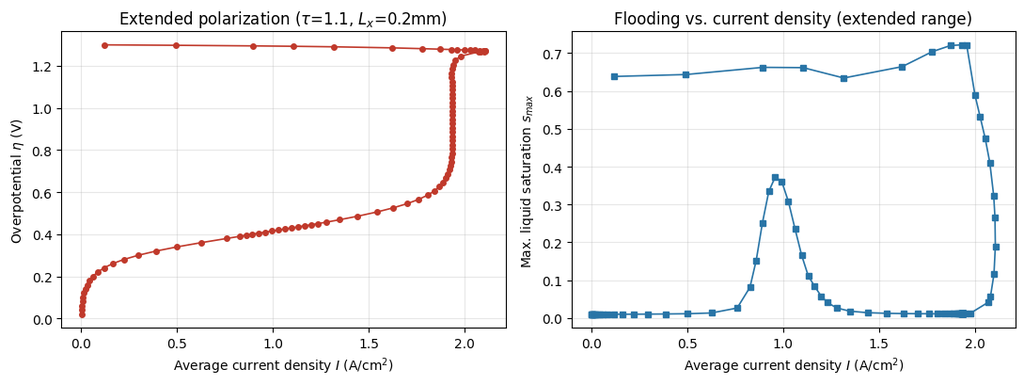

Cell 12 출력 — 확장 분극곡선(좌)과 flooding-전류 관계(우)

왼쪽: η vs I. η가 1.5까지 밀어붙여지는 동안 I가 어떻게 움직이는지. 오른쪽: I vs s_max — **두 개의 뚜렷한 flooding 사건**이 봉우리 형태로 보인다.

## 4.2 base case와의 정량 대조

| η | base(τ=1.5,Lx=0.3mm) I | 이번(τ=1.1,Lx=0.2mm) I | base s_max | 이번 s_max |
| --- | --- | --- | --- | --- |
| 0.30 | 0.2938 | 0.2979 | 0.01005 | 0.0103 |
| 0.32 | 0.3833 | 0.3909 | 0.01114 | 0.0106 |
| 0.34 | 0.4875 | 0.5014 | 0.01572 | 0.0113 |
| 0.35 | 0.5406 | ~0.564(보간) | **0.09089** | ~0.012 |
| 0.356(base fold) | (fold) | (매끄럽게 통과) | — | — |
| 1.30 | (계산 안 됨) | 0.1192(붕괴 후) | — | 0.6383 |

**핵심 관찰**: η≤0.35 구간에서 두 설정의 I는 1~4%밖에 차이 나지 않는다. 갈라지는 것은 오로지 **s_max의 개시 시점** — base는 η=0.35에서 이미 튀지만 이번 설정은 η=0.38까지 버틴다. τ↓·Lx↓는 **동역학 지배 구간을 바꾸지 않고, 물질전달(flooding) 구간의 시작을 늦춘다.**

## 4.3 국면 ① — 동역학 지배 구간 (η ≤ 0.38)

| η | I (A/cm²) | s_max |
| --- | --- | --- |
| 0.02 | 0.0039 | 0.0099 |
| 0.20 | 0.0617 | 0.0100 |
| 0.36 | 0.6267 | 0.0132 |
| 0.38 | 0.7612 | 0.0263 |

s_max가 §3.9에서 확인한 **스무딩 바닥값(≈0.01)** 근처에 머무는 구간 — 실질적으로 액상이 없는 단상 상태. I는 Tafel 지수를 따라 거의 지수적으로 증가한다. base case와 거의 완전히 겹치는 구간이기도 하다(§4.2).

## 4.4 국면 ② — 1차 flooding 스파이크: 자가 해소 (η 0.38 ~ 0.45)

```
eta=0.4000: REJECTED s_max jumped 0.0263 -> 0.2520 (거부, 스텝 축소)
eta=0.3900: I=0.8279, s_max=0.0810  (flooding-capped 세밀 스텝 시작)
eta=0.4100: I=0.9599, s_max=0.3728  <- 이 구간 최댓값
eta=0.4200: I=1.0286, s_max=0.3076
eta=0.4400: I=1.1658, s_max=0.0831
eta=0.4500: I=1.2323, s_max=0.0407  (거의 원래 바닥 수준으로 복귀)
```

s_max가 **0.026 → 0.373 → 0.041로 솟았다가 스스로 가라앉는다** — 그동안 I는 계속(끊김 없이) 증가한다. 물이 순간적으로 차올랐다가 대류·모세관 배출이 이를 다시 씻어내는 것으로 읽을 수 있는 패턴. 이 구간에서 flooding cap(§3.15)이 스텝을 세밀하게 유지한 덕분에 이 자가 해소 과정이 로그에 해상도 있게 남아 있다.

## 4.5 국면 ③ — 한계전류 고원 (η 0.45 ~ 1.25)

```
eta=0.5856: I=1.8071, s_max=0.0110
eta=0.9256: I=1.9373, s_max=0.0108   <- 이 구간 최댓값 근처
eta=1.1456: I=1.9333, s_max=0.0108
```

s_max는 다시 스무딩 바닥값(0.0108)에 머문다 — 이 구간도 실질적으로 단상.

## 4.6 국면 ④ — 2차 flooding 개시: 파국적 (η 1.265 ~ 1.277)

```
eta=1.2656: I=2.0709, s_max=0.0416
eta=1.2856: REJECTED s_max jumped 0.0416 -> 0.9395  (첫 시도, 즉시 거부)
...세밀 재시도...
eta=1.2702: I=2.1076, s_max=0.1895   <- 이 실행 전체의 최고 전류
eta=1.2732: I=2.0788, s_max=0.4102
eta=1.2771: I=1.9314, s_max=0.7218   <- s_max 최댓값
```

1차 스파이크(국면②)와 달리 s_max가 **0.04에서 0.94까지** 단번에 튀려 했다 — 훨씬 격렬한 전이. 여기서 전체 실행의 최고 전류(**2.1076 A/cm²**)가 나오는데, 이는 s_max가 아직 0.19에 불과할 때다 — 즉 최고점은 flooding이 본격화되기 **직전**에 찍힌다.

## 4.7 국면 ⑤ — 전류 붕괴 (η 1.277 ~ 1.2994)

```
eta=1.2813: I=1.7777, s_max=0.7036
eta=1.2901: I=1.3172, s_max=0.6342
eta=1.2926: I=1.1054, s_max=0.6616   (Newton 실패 1회 겪은 뒤)
eta=1.2973: I=0.4940, s_max=0.6434
eta=1.2994: I=0.1192, s_max=0.6383   <- 최종 수락 지점
```

**η가 겨우 0.022 이동하는 동안 I가 2.11 → 0.12로 붕괴**(94% 감소)한다. 그런데 주목할 것: **s_max는 이 구간에서 더 오르지 않고 오히려 0.72→0.64로 살짝 내려간다.** flooding이 계속 심해져서 전류가 죽는 게 아니라, **s_max가 대략 고정된 채로 I만 무너진다** — 단순한 “물이 계속 차오른다”는 서사로는 설명되지 않는 대목이며, Part 5의 첫 탐구 주제로 이어진다.

## 4.8 정지의 해부

```
eta=1.3016: 물리 위반 (I=-3267 A/m^2) 거부
eta=1.3026: 물리 위반 (I=-5783 A/m^2) 거부
eta=1.3010: 물리 위반 (I=-2089 A/m^2) 거부, 연속 실패로 8x 축소
ds < ds_min -> BIG JUMP 시도
  x1.0 (eta=1.3194): 물리 위반 (I=-112728 A/m^2) 실패
  x2.0 (eta=1.3394): Newton 자체가 실패
  x3.0 (eta=1.3594): Newton 자체가 실패
=> 정지. eta=1.2994, I=0.1192 A/cm^2가 최종 상태.
```

정지 직전 시도들의 I가 **-3267 → -5783 → -2089 → -112728 A/m²**로, §3.12에서 만든 `check_physical`의 L2 투영 오버슛 방어가 정확히 왜 필요했는지를 실전에서 보여준다 — 방어가 없었다면 이 값들이 그대로 “수렴한 해”로 받아들여졌을 것이다.

## 4.9 이 지점은 fold인가 — 이 노트북은 답하지 않는다

로그의 마지막 줄:

> STOPPED SHORT of the target at eta=1.2994 – a genuine candidate for follow-up investigation (this notebook does not classify it further).

## 4.10 논문과의 정성적 대응 — 참고용

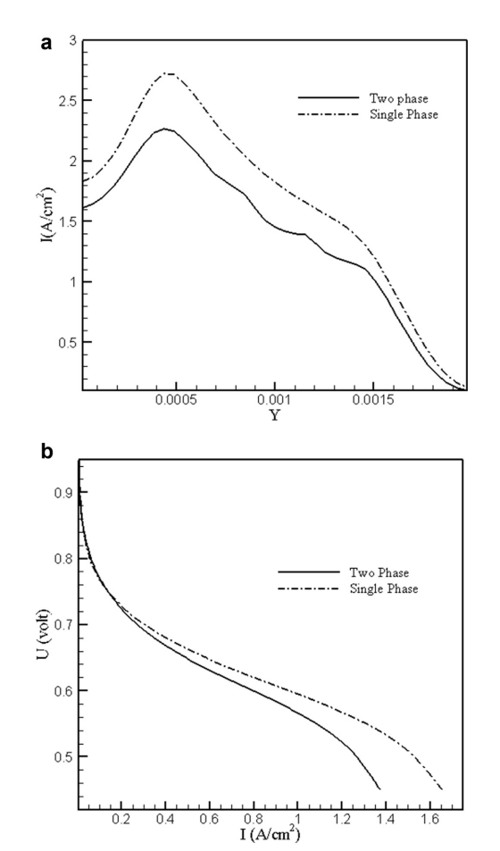

Fig. 8 — 논문의 단상/이상 국소전류밀도 비교

논문 Fig. 8a도 국소전류밀도가 채널을 따라 **비단조**(피크를 찍고 감소)임을 보인다 — 다만 이건 **고정된 η=0.55에서 공간(y) 방향**의 프로파일이고, 이번 실행에서 본 것은 **η 방향(연속 파라미터 공간)의 붕괴**다. 메커니즘이 같다고 주장할 근거는 없지만, “이 M² 모델 계열에서 국소·전역 전류가 단조롭지 않은 거동을 보이는 것 자체는 낯설지 않다”는 정도의 정성적 맥락은 된다.

# Part 5. 탐구 주제 — missing physics와 hybrid model

## 5-A. 선결 문제: 붕괴는 물리인가 수치인가

## 5A.1 왜 이 질문이 먼저인가

Part 4에서 본 붕괴(η 1.277~1.2994, I가 2.11→0.12)를 다짜고짜 “missing physics”의 증거로 삼으면 안 된다. §4.7에서 지적했듯 s_max가 오히려 살짝 **내려가는데** I만 무너지는 패턴은, 물리적 fold라기보다 **수치적 탈진**(격자 미해상, 안정화 부재, 투영 오버슛의 누적)일 가능성을 배제할 수 없다. 이 구분을 먼저 하지 않으면, 나중에 학습시킬 closure가 실은 존재하지도 않는 물리적 결손을 메우려다 수치 아티팩트를 학습하게 된다.

## 5A.2 메쉬 수렴

현재 24×60. §2.D(함수 3, 15)에서 본 SVD 진단 도구들은 이미 이 프로젝트에 있다 — `fold_svd_sweep`을 η=1.25~1.30 구간에, 36×90(arclength 세밀 노트북이 이미 쓰는 해상도, 프로젝트 메모에 기록된 대로), 48×120까지 세 단계로 돌려 붕괴 지점의 위치와 그때의 s_max 값이 격자에 따라 수렴하는지 본다. 수렴하지 않고 격자를 세밀화할수록 위치가 계속 이동하면, 최소한 부분적으로는 미해상(under-resolution) 문제다.

## 5A.4 이미 있는 도구로 즉시 가능한 것

- `fold_svd_sweep`(§2.D-20)으로 η=1.25~1.30을 촘촘히(0.001 간격) 스윕, 등화 최소특이값의 추세를 base case의 확인된 fold(1.6e-5→2.9e-10)와 비교
- `diagnose_fold_point`(§2.D-15)로 단순 fold vs 더 높은 여차원 축퇴 판정(횡단성 검사까지)
- `check_outlet_flow`(§2.D-19)를 이 지점에서도 실행 — base case의 두 번째 stuck point에서 나왔던 “배출구 유출 가정이 flooding 심화 시 무너진다”는 가설이 여기서도 재현되는지

## 5-B. missing physics 후보

## 5B.1 이 코드가 스스로 고백한 미지수

§2.15의 표(논문에 없는 파라미터)가 정확히 후보 목록이다: `tau_brug`(이번 실행의 조작 변수 자체), `Ea_orr`(문헌 대입값), Leverett 다항식 계수(재료 의존적인데 하드코딩), Corey 지수 `n=3`(두 논문 모두 확정값이지만 특정 GDL 재질에 대한 실측일 뿐 일반해가 아님).

## 5B.2 구조적 가정: s(C_w) 평형

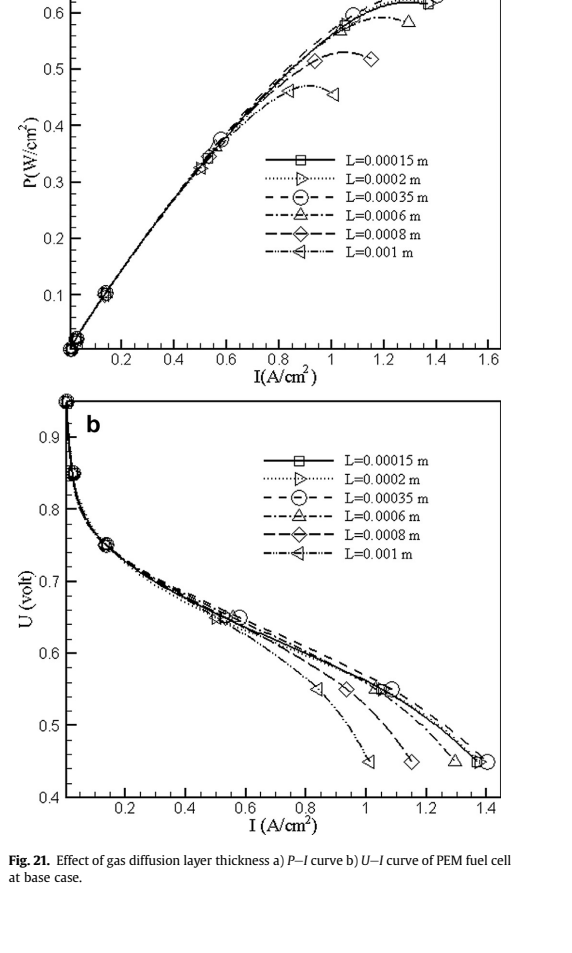

Fig. 21/22 — 논문의 GDL 두께 스윕: L=0.0002m(=0.2mm)이 실제로 포함됨

§2.5에서 본 평형 관계 $s=s(C_w)$는 **응축·증발이 순간적**이라고 가정한다. 실제로는 유한한 시간상수를 갖는 속도론이 있을 수 있다 — 특히 이번 노트북처럼 **정상상태 continuation으로 η를 빠르게 훑는** 상황에서는, 각 η에서 “이미 평형에 도달한 상태”를 계산하고 있는 것이지, 그리로 가는 과정은 모델에 없다. 시간 스케일이 실제 운전보다 훨씬 빠르게 압축되어 있다는 뜻이다.

## 5B.3 (1−s) 차단 인자와 등온 가정

§2.11의 Tafel 식의 $(1-s)$는 촉매 활성면적 감소를 선형으로만 근사한다 — 실제 agglomerate 구조에서는 이보다 복잡한 형태일 수 있다(Xie et al. 2019가 이 부분을 개선된 agglomerate 촉매층 모델로 다룸, 이전 대화에서 검토한 후보 논문). 등온 가정도 명시적 결손이다 — 논문 결론부 스스로 “future works will include considering temperature change”라고 인정한다. 이 코드에는 에너지 방정식이 아예 없다.

## 5B.4 GDL 두께 스윕과의 연결

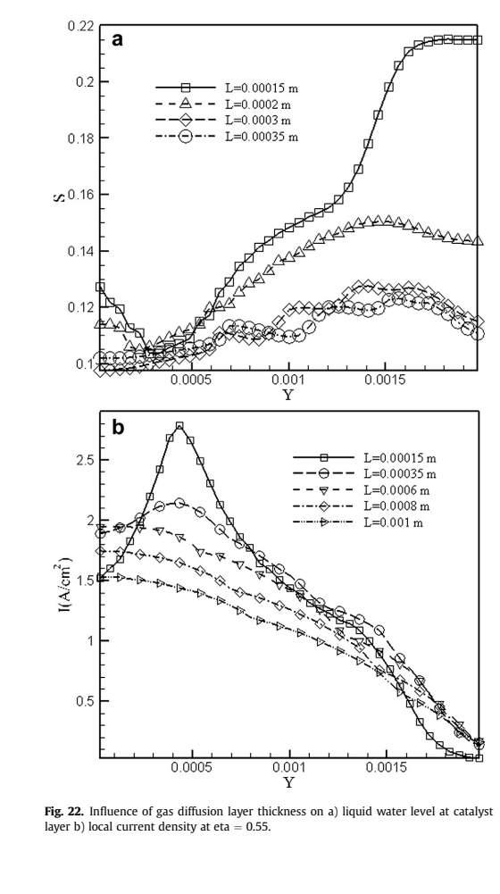

Fig. 21/22 하단 — s(y) 프로파일, 국소전류밀도

논문 자신의 Fig. 21/22가 L=0.15~1.0mm 스윕에서 “0.35mm 이하로는 전류가 두께에 별로 안 변한다”고 결론짓는데, 이번 노트북은 그보다도 얇은 **0.2mm**에서 η를 훨씬 멀리(1.5까지) 밀어붙였다. 이 조합(얇은 GDL × 높은 η)이 논문의 실험 범위를 벗어난 외삽 영역이라는 점도 §5A의 “물리 vs 수치” 판정에서 고려해야 한다 — 모델 자체가 검증되지 않은 영역일 수 있다.

## 5-C. FEML을 이 코드에 얹을 수 있는가 (정성적 서술, FEniCSx+PyTorch 기준)

## 5C.1 FEML의 골격

Farsi, Bouziani & Ham (2026)의 틀: 알려진 물리는 약형식 잔차 $F(u_\theta, G_\theta(u_\theta); v)=0$로 그대로 두고, **모르는 관계만** 학습 연산자 $G_\theta$로 바꿔 그 잔차 안에 끼워 넣는다. 손실은 $G_\theta$의 직접 관측이 아니라 — 종종 관측 불가능한 — **PDE 해**(변위, 온도 등)와 관측 데이터의 차이로 정의된다. 이 노트북의 언어로 옮기면: $s$ 표현식이나 Tafel식은 그대로, $D_{eff}(s)$나 $dJ/ds$ 같은 자리만 신경망으로 바꾸고, 손실은 (예를 들어) 분극곡선 $I(\eta)$나 막 프로파일과의 차이로 정의한다는 것.

## 5C.2 가장 잘 맞는 대응: 열전도 예제 ↔︎ D_eff(s)

$$D_{eff}^{O2} = \rho_g[\varepsilon(1-s)]^\tau D^{O2}_g \quad\longrightarrow\quad D_{eff}^{O2} = \rho_g\,\mathcal G_\theta(s)\,D^{O2}_g$$

$\tau$는 논문에 값이 없고(§2.15) 이번 실행의 조작 변수이기도 하다 — “한 개의 지수짜리 멱법칙”을 학습 대상으로 바꾸는 것은 이 코드에서 가장 자연스러운 첫걸음이다. FEML 예제의 MLP 구조(은닉층 2~3개, 30 뉴런, ReLU+Softplus/Sigmoid)를 거의 그대로 가져다 쓸 수 있는 규모다.

## 5C.3 두 번째 후보: dJ/ds (모세관력)

§2.6의 Leverett 다항식은 특정 GDL 재질에 대한 준경험적 피팅이다. FEML의 구조 보존(symmetry-preserving) 설계 철학(§3.1.2 — 임의의 변형률→응력 사상 대신, 등방성 대칭을 만족하도록 두 개의 스칼라 함수로 텐서 사상을 제한)을 이 코드에 옮기면: $dJ/ds$를 임의의 신경망이 아니라, **소수성/친수성 두 분기의 부호 대칭**($u=1-s$ 치환에 대한 반대칭, §2.D 함수 7)을 구조적으로 유지하는 형태로 제한할 수 있다 — 아무 함수나 배우는 것보다 데이터 효율이 좋아진다는 것이 FEML의 핵심 논거(§2 discussion, 힘-변위 6쌍만으로 연화 법칙을 복원한 사례).

## 5C.4 왜 solution surrogate가 아니라 operator를 배워야 하는가

FEML이 강조하는 차별점: FNO/PINO류는 “이 형상·경계조건에서의 해”를 통째로 배우는 반면, FEML은 **닫힘 관계 자체**를 배워 형상·경계조건이 바뀌어도 재사용한다(§1.2.3의 2D 압축시험 → 3D 비틀림판 zero-shot 전이). 이 코드로 옮기면: $D_{eff}(s)$를 이번 실행(τ=1.1, Lx=0.2mm, η≤1.5)의 데이터로 학습한 뒤, **다른 Lx·다른 채널 형상·다른 τ 진짜 값**(만약 실측이 있다면)으로 옮겨 써도 다시 학습할 필요가 없어야 한다는 것이 목표가 된다 — 이번 프로젝트가 지금 하고 있는 “파라미터를 바꿔가며 sweep”의 상당 부분을 대체할 잠재력.

## 5C.5 Firedrake → FEniCSx 이식의 실질적 관문

FEML은 Firedrake의 `pyadjoint` 계열 미분 가능 인터페이스(및 저자들 자신의 UFL 외부 함수 인터페이스 연구)에 의존해 “PDE 솔버를 통째로 미분”한다. **FEniCSx(dolfinx)에는 이에 대응하는 성숙한 adjoint 인프라가 기본 제공되지 않는다.** 실질적으로 두 경로가 있다:

- UFL 외부 연산자(external operator) 확장을 이용해, PyTorch 텐서를 UFL 계수처럼 잔차 안에 심고 forward 값과 **Jacobian 작용(action)**을 직접 제공하는 방식 — FEML 저자들이 Firedrake용으로 개발한 것과 같은 개념을 FEniCSx 쪽에서 별도로 마련해야 한다.
- 학습 파라미터에 대한 손실의 그래디언트를 discrete adjoint로 직접 구현 — 정상상태 잔차이므로 PETSc SNES의 Jacobian(§3.8에서 이미 UFL 자동미분으로 얻고 있는 바로 그것)을 재사용해 $\partial u/\partial\theta$를 선형계 하나로 구할 수 있다(§2.D-13의 Keller bordering이 쓰는 것과 같은 부류의 선형대수).

정성적으로: **UFL이 물리 쪽 미분(잔차의 상태에 대한 미분)은 이미 자동으로 준다** — 이건 이 코드가 지금도 매 Newton 스텝마다 쓰고 있는 것과 같다. 다리를 놓아야 하는 부분은 그 사슬을 **학습 파라미터 θ까지** 잇는 것뿐이다.

## 5C.6 이 코드 고유의 장벽 두 가지

**① 계산 비용.** 이 노트북 자체가 η=0.02에서 1.30까지 도달하는 데 **약 48분**(로그의 `Elapsed time: 2868s`) 걸렸다. FEML이 스스로 한계로 지적하는 “반복적인 adjoint 풀이가 대형 3차원·고비선형 문제에서 비싸다”는 우려가, 이 코드에서는 **순전파 한 번**만으로도 이미 현실이다. 학습 루프가 매 epoch마다 이런 순전파(+adjoint)를 여러 번 요구한다면, 학습 자체가 비현실적으로 느려질 수 있다 — §3.1의 Cell 10이 이미 라이브러리의 검증된 continuation 대신 문제 특화된 적응 스텝을 새로 짠 것처럼, 학습용으로는 훨씬 저렴한 대리 설정(더 거친 격자, 좁은 η 범위)이 먼저 필요할 것이다.

**② VI box constraint와 적응 continuation이 학습 루프와 공존하는가.** §3.10의 `vinewtonrsls`는 매 Newton 반복마다 활성 제약 집합(active set)이 바뀔 수 있다 — 이는 해가 θ에 대해 매끄럽게 미분 가능하지 않을 수 있다는 뜻이다(활성 집합이 바뀌는 경계에서 미분이 불연속). §3.14의 적응 스텝 크기 로직(성공/실패에 따라 ds가 이산적으로 바뀜)도 마찬가지로 θ에 대해 매끄럽지 않은 분기를 만든다. FEML의 예제들은 전부 이런 제약·분기가 없는 매끄러운 문제였다는 점을 상기할 필요가 있다.

## 5C.7 식별 가능성 문제

FEML 스스로 한계로 명시하는 부분(§2 discussion): “여러 연산자·파라미터가 비슷한 관측량을 만들어낼 때 식별 불가능성이 생길 수 있다.” 이 코드에서는 이게 추상적 우려가 아니라 **구체적으로 위험**하다 — $\tau$(Bruggeman), $dJ/ds$(모세관), $n$(Corey)이 **동시에** 미지인데, 셋 다 오직 같은 두 관측량(η에 대한 $I$, $s_{max}$)에만 영향을 준다. 셋을 한꺼번에 학습시키면 서로 다른 (τ, dJ/ds, n) 조합이 같은 I(η) 곡선을 낼 수 있다 — 데이터가 어느 게 진짜인지 구분해 주지 못한다. 하나씩 고정하고 나머지를 학습하는 설계, 혹은 §5B.4처럼 논문 자신의 실측 스윕(Fig. 21~27)을 추가 관측 축으로 동원해 자유도를 줄이는 접근이 필요하다.

## 5-D. 설계와 한계

## 5D.1 ground truth 3단 구성

“학습된 모델과 대조만 하는 것은 부족하다”는 문제의식에 맞춰 FEML §1.2.3(2D 압축시험 → 3D 비틀림판)의 논리를 이 코드에 옮기면:

1. **진리(ground truth)**: 현재의 full M² 모델(고정된 τ, 논문 Leverett 다항식) 그대로.
2. **축소 모델**: `single_phase=True`로 액상을 아예 끄거나, τ를 학습 대상으로 비워둔 버전에 학습된 closure를 끼운다.
3. **전이 검증**: 학습에 쓰지 않은 파라미터·형상(다른 Lx, 다른 채널 폭 w_ch/w_rb)으로 **전이**시켜, 학습된 closure가 붕괴 지점(§4.7~4.9)의 위치나 한계전류(§4.5)를 얼마나 잘 예측하는지 확인한다. FEML의 2D→3D 전이(상대오차 ~0.1%)가 그 성공의 기준선이 된다.

## 5D.2 라벨 품질 문제

§3.13에서 지적한 `I_ave`(산술평균, 논문 Eq. 33의 경계적분과 다름)를 고치지 않고 학습 라벨로 쓰면, 학습된 $D_{eff}$나 $dJ/ds$가 **실제 물리가 아니라 투영 오버슛을 보정하는 방향으로 왜곡**될 위험이 있다. §5A(수치 vs 물리 판정)와 이 문제는 독립이 아니다 — 라벨 자체의 결함을 먼저 걷어내지 않으면, missing physics 탐구가 수치 아티팩트를 물리로 오인해 학습하는 결과를 낳을 수 있다.

## 5D.3 하이브리드로도 못 메우는 것 — 정직한 한계

- **시간항 부재**: 이 코드는 정상상태다. 물방울 이탈, 채널 내 slug 형성 같은 **동적** flooding(Carton et al.이 VOF로 다룬 영역)은 어떤 closure를 학습해도 이 정상상태 틀 안에서는 표현할 수 없다 — 애초에 시간미분이 방정식에 없다.
- **채널 내부 유동 부재**: 논문 스스로 “flow and transport in channels have not been considered”라고 명시한다(§4.9). 채널/GDL 계면에서의 액적 형상, 젖음성의 실제 영향은 이 2D GDL-only 도메인 밖의 이야기다.
- **실험 데이터 부재**: 지금까지의 모든 “검증”은 다른 시뮬레이션(base case) 또는 같은 논문 내부 대조다. 실측 분극곡선이나 가시화 데이터 없이는, 학습된 closure가 실제 재료 거동에 더 가까워졌는지 검증할 방법이 없다 — FEML 예제들도 전부 synthetic(다른 알려진 법칙으로 생성한) 데이터였다는 점과 같은 한계를 공유한다.

# 참고자료

## 참고문헌

- M. Abdollahzadeh, J.C. Pascoa, A.A. Ranjbar, Q. Esmaili, “Analysis of PEM fuel cell cathode two-dimensional modeling,” *Energy* 68 (2014) 478–494.
- M.-H. Chang, F. Chen, H.-S. Teng, “Effects of two-phase transport in the cathode gas diffusion layer on the performance of a PEMFC,” *J. Power Sources* 160 (2006) 268–276.
- A. Farsi, N. Bouziani, D.A. Ham, “Missing Physics Discovery through Fully Differentiable Finite Element-Based Machine Learning,” *Research Square preprint* (2026), DOI: 10.21203/rs.3.rs-8641881/v1.
- 이 저장소: `pemfc_lib.py` (PSE Lab, FEniCSx 0.11 구현), `PEMFC_Tau1_1_Lx0_2mm_HighEta_Exploration.ipynb`, `base_case.npz`.

## 이 슬라이드에서 미확인으로 남긴 것

- η≈1.2994 정지가 fold인지 수치적 탈진인지 (§5A) — `fold_svd_sweep` / `diagnose_fold_point` 실행 필요
- SUPG 재도입 시 붕괴 지점이 이동하는지 (§5A.3)
- 메쉬 수렴 (24×60 → 36×90 → 48×120) (§5A.2)
- τ, dJ/ds, n_corey 동시 학습의 식별 가능성 문제에 대한 구체적 해법 (§5C.7)